# Open Meteo Weather Exploration

davegoblue

2024-12-01

## Background

Open-Meteo maintains an [API for historical weather](https://open-meteo.com/en/docs/historical-weather-api) that allows for non-commercial usage of historical weather data maintained by the website.

This file builds on _v001, _v002, _v003, and _v004 to run exploratory analysis on some historical weather data.

## Functions and Libraries

The exploration process uses tidyverse, ranger, several generic custom functions, and several functions specific to Open Meteo processing. First, tidyverse, ranger, and the generic functions are loaded:

```r
library(tidyverse) # tidyverse functionality is included throughout
library(ranger) # predict() does not work on ranger objects unless ranger has been called
source("./Generic_Added_Utility_Functions_202105_v001.R") # Basic functions
```

Next, specific functions written in _v001, _v002, _v003, and _v004 are sourced:

```r
source("./SimpleOneVar_Functions_202411_v001.R") # Functions for basic single variable analysis
source("./OpenMeteo_NextBest_202411_v001.R") # Functions for finding 'next best' predictor given existing model
source("./OpenMeteo_Functions_202411_v001.R") # Core functions for loading, processing, analysis of Open Meteo
```

Key mapping tables for available metrics are also copied:

```r
hourlyMetrics <- "temperature_2m,relativehumidity_2m,dewpoint_2m,apparent_temperature,pressure_msl,surface_pressure,precipitation,rain,snowfall,cloudcover,cloudcover_low,cloudcover_mid,cloudcover_high,shortwave_radiation,direct_radiation,direct_normal_irradiance,diffuse_radiation,windspeed_10m,windspeed_100m,winddirection_10m,winddirection_100m,windgusts_10m,et0_fao_evapotranspiration,weathercode,vapor_pressure_deficit,soil_temperature_0_to_7cm,soil_temperature_7_to_28cm,soil_temperature_28_to_100cm,soil_temperature_100_to_255cm,soil_moisture_0_to_7cm,soil_moisture_7_to_28cm,soil_moisture_28_to_100cm,soil_moisture_100_to_255cm"
dailyMetrics <- "weathercode,temperature_2m_max,temperature_2m_min,apparent_temperature_max,apparent_temperature_min,precipitation_sum,rain_sum,snowfall_sum,precipitation_hours,sunrise,sunset,windspeed_10m_max,windgusts_10m_max,winddirection_10m_dominant,shortwave_radiation_sum,et0_fao_evapotranspiration"

hourlyDescription <- "Air temperature at 2 meters above ground\nRelative humidity at 2 meters above ground\nDew point temperature at 2 meters above ground\nApparent temperature is the perceived feels-like temperature combining wind chill factor, relative humidity and solar radiation\nAtmospheric air pressure reduced to mean sea level (msl) or pressure at surface. Typically pressure on mean sea level is used in meteorology. Surface pressure gets lower with increasing elevation.\nAtmospheric air pressure reduced to mean sea level (msl) or pressure at surface. Typically pressure on mean sea level is used in meteorology. Surface pressure gets lower with increasing elevation.\nTotal precipitation (rain, showers, snow) sum of the preceding hour. Data is stored with a 0.1 mm precision. If precipitation data is summed up to monthly sums, there might be small inconsistencies with the total precipitation amount.\nOnly liquid precipitation of the preceding hour including local showers and rain from large scale systems.\nSnowfall amount of the preceding hour in centimeters. For the water equivalent in millimeter, divide by 7. E.g. 7 cm snow = 10 mm precipitation water equivalent\nTotal cloud cover as an area fraction\nLow level clouds and fog up to 2 km altitude\nMid level clouds from 2 to 6 km altitude\nHigh level clouds from 6 km altitude\nShortwave solar radiation as average of the preceding hour. This is equal to the total global horizontal irradiation\nDirect solar radiation as average of the preceding hour on the horizontal plane and the normal plane (perpendicular to the sun)\nDirect solar radiation as average of the preceding hour on the horizontal plane and the normal plane (perpendicular to the sun)\nDiffuse solar radiation as average of the preceding hour\nWind speed at 10 or 100 meters above ground. Wind speed on 10 meters is the standard level.\nWind speed at 10 or 100 meters above ground. Wind speed on 10 meters is the standard level.\nWind direction at 10 or 100 meters above ground\nWind direction at 10 or 100 meters above ground\nGusts at 10 meters above ground of the indicated hour. Wind gusts in CERRA are defined as the maximum wind gusts of the preceding hour. Please consult the ECMWF IFS documentation for more information on how wind gusts are parameterized in weather models.\nET0 Reference Evapotranspiration of a well watered grass field. Based on FAO-56 Penman-Monteith equations ET0 is calculated from temperature, wind speed, humidity and solar radiation. Unlimited soil water is assumed. ET0 is commonly used to estimate the required irrigation for plants.\nWeather condition as a numeric code. Follow WMO weather interpretation codes. See table below for details. Weather code is calculated from cloud cover analysis, precipitation and snowfall. As barely no information about atmospheric stability is available, estimation about thunderstorms is not possible.\nVapor Pressure Deificit (VPD) in kilopascal (kPa). For high VPD (>1.6), water transpiration of plants increases. For low VPD (<0.4), transpiration decreases\nAverage temperature of different soil levels below ground.\nAverage temperature of different soil levels below ground.\nAverage temperature of different soil levels below ground.\nAverage temperature of different soil levels below ground.\nAverage soil water content as volumetric mixing ratio at 0-7, 7-28, 28-100 and 100-255 cm depths.\nAverage soil water content as volumetric mixing ratio at 0-7, 7-28, 28-100 and 100-255 cm depths.\nAverage soil water content as volumetric mixing ratio at 0-7, 7-28, 28-100 and 100-255 cm depths.\nAverage soil water content as volumetric mixing ratio at 0-7, 7-28, 28-100 and 100-255 cm depths."
dailyDescription <- "The most severe weather condition on a given day\nMaximum and minimum daily air temperature at 2 meters above ground\nMaximum and minimum daily air temperature at 2 meters above ground\nMaximum and minimum daily apparent temperature\nMaximum and minimum daily apparent temperature\nSum of daily precipitation (including rain, showers and snowfall)\nSum of daily rain\nSum of daily snowfall\nThe number of hours with rain\nSun rise and set times\nSun rise and set times\nMaximum wind speed and gusts on a day\nMaximum wind speed and gusts on a day\nDominant wind direction\nThe sum of solar radiaion on a given day in Megajoules\nDaily sum of ET0 Reference Evapotranspiration of a well watered grass field"

# Create tibble for hourly metrics
tblMetricsHourly <- tibble::tibble(metric=hourlyMetrics %>% str_split_1(","),
                                   description=hourlyDescription %>% str_split_1("\n")
                                   )
tblMetricsHourly %>%
    print(n=50)
```

```
## # A tibble: 33 × 2
##    metric                        description
##    <chr>                         <chr>
##  1 temperature_2m                Air temperature at 2 meters above ground
##  2 relativehumidity_2m           Relative humidity at 2 meters above ground
##  3 dewpoint_2m                   Dew point temperature at 2 meters above ground
##  4 apparent_temperature          Apparent temperature is the perceived feels-li…
##  5 pressure_msl                  Atmospheric air pressure reduced to mean sea l…
##  6 surface_pressure              Atmospheric air pressure reduced to mean sea l…
##  7 precipitation                 Total precipitation (rain, showers, snow) sum …
##  8 rain                          Only liquid precipitation of the preceding hou…
##  9 snowfall                      Snowfall amount of the preceding hour in centi…
## 10 cloudcover                    Total cloud cover as an area fraction
## 11 cloudcover_low                Low level clouds and fog up to 2 km altitude
## 12 cloudcover_mid                Mid level clouds from 2 to 6 km altitude
```

[output cut: 21 more lines]

```r
# Create tibble for daily metrics
tblMetricsDaily <- tibble::tibble(metric=dailyMetrics %>% str_split_1(","),
                                  description=dailyDescription %>% str_split_1("\n")
                                   )
tblMetricsDaily
```

```
## # A tibble: 16 × 2
##    metric                     description
##    <chr>                      <chr>
##  1 weathercode                The most severe weather condition on a given day
##  2 temperature_2m_max         Maximum and minimum daily air temperature at 2 me…
##  3 temperature_2m_min         Maximum and minimum daily air temperature at 2 me…
##  4 apparent_temperature_max   Maximum and minimum daily apparent temperature
##  5 apparent_temperature_min   Maximum and minimum daily apparent temperature
##  6 precipitation_sum          Sum of daily precipitation (including rain, showe…
##  7 rain_sum                   Sum of daily rain
##  8 snowfall_sum               Sum of daily snowfall
##  9 precipitation_hours        The number of hours with rain
## 10 sunrise                    Sun rise and set times
## 11 sunset                     Sun rise and set times
## 12 windspeed_10m_max          Maximum wind speed and gusts on a day
## 13 windgusts_10m_max          Maximum wind speed and gusts on a day
## 14 winddirection_10m_dominant Dominant wind direction
## 15 shortwave_radiation_sum    The sum of solar radiaion on a given day in Megaj…
## 16 et0_fao_evapotranspiration Daily sum of ET0 Reference Evapotranspiration of …
```

A previously existing dataset is loaded, with key analysis variables defined in a vector:

```r
# Load previous data
allCity <- readFromRDS("allCity_20241116")

# Get core training variables
varsTrain <- getVarsTrain(allCity)
varsTrain
```

```
##  [1] "hour"                          "temperature_2m"
##  [3] "relativehumidity_2m"           "dewpoint_2m"
##  [5] "apparent_temperature"          "pressure_msl"
##  [7] "surface_pressure"              "precipitation"
##  [9] "rain"                          "snowfall"
## [11] "cloudcover"                    "cloudcover_low"
## [13] "cloudcover_mid"                "cloudcover_high"
## [15] "shortwave_radiation"           "direct_radiation"
## [17] "direct_normal_irradiance"      "diffuse_radiation"
## [19] "windspeed_10m"                 "windspeed_100m"
## [21] "winddirection_10m"             "winddirection_100m"
## [23] "windgusts_10m"                 "et0_fao_evapotranspiration"
## [25] "weathercode"                   "vapor_pressure_deficit"
## [27] "soil_temperature_0_to_7cm"     "soil_temperature_7_to_28cm"
## [29] "soil_temperature_28_to_100cm"  "soil_temperature_100_to_255cm"
## [31] "soil_moisture_0_to_7cm"        "soil_moisture_7_to_28cm"
## [33] "soil_moisture_28_to_100cm"     "soil_moisture_100_to_255cm"
## [35] "year"                          "doy"
```

```r
# Assign default label
keyLabel <- genericKeyLabelOM()
keyLabel
```

```
## [1] "predictions based on pre-2022 training data applied to 2022 holdout dataset"
```

The correlation heatmap is reproduced, with functions that borrowing from the recipe at [STHDA](http://www.sthda.com/english/wiki/ggplot2-quick-correlation-matrix-heatmap-r-software-and-data-visualization):

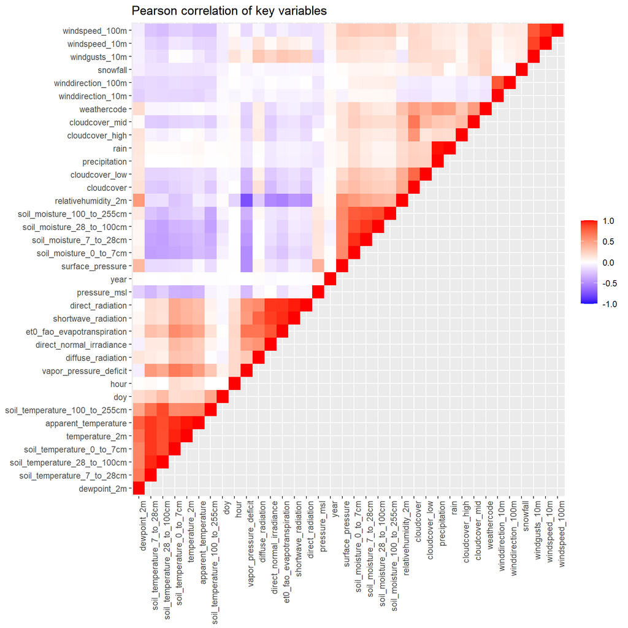

```r
# Default function
corVarsTrain <- makeHeatMap(allCity, vecSelect=varsTrain, returnData=TRUE)
```

```r
corVarsTrain %>% filter(Var1!=Var2) %>% arrange(desc(value)) %>% print(n=20)
```

```
## # A tibble: 630 × 3
##    Var1                          Var2                         value
##    <fct>                         <fct>                        <dbl>
##  1 rain                          precipitation                0.989
##  2 apparent_temperature          temperature_2m               0.984
##  3 direct_radiation              shortwave_radiation          0.974
##  4 temperature_2m                soil_temperature_0_to_7cm    0.962
##  5 soil_temperature_28_to_100cm  soil_temperature_7_to_28cm   0.952
##  6 shortwave_radiation           et0_fao_evapotranspiration   0.944
##  7 apparent_temperature          soil_temperature_0_to_7cm    0.942
##  8 soil_moisture_7_to_28cm       soil_moisture_0_to_7cm       0.940
##  9 windspeed_100m                windspeed_10m                0.940
## 10 direct_radiation              et0_fao_evapotranspiration   0.928
## 11 direct_radiation              direct_normal_irradiance     0.922
## 12 soil_moisture_28_to_100cm     soil_moisture_7_to_28cm      0.922
## 13 soil_temperature_0_to_7cm     soil_temperature_7_to_28cm   0.919
## 14 apparent_temperature          soil_temperature_7_to_28cm   0.918
## 15 temperature_2m                soil_temperature_7_to_28cm   0.917
## 16 shortwave_radiation           direct_normal_irradiance     0.901
## 17 windspeed_10m                 windgusts_10m                0.884
## 18 soil_temperature_100_to_255cm soil_temperature_28_to_100cm 0.863
## 19 soil_moisture_100_to_255cm    soil_moisture_28_to_100cm    0.859
## 20 apparent_temperature          soil_temperature_28_to_100cm 0.853
## # ℹ 610 more rows
```

The correlation heatmap is produced for a single city:

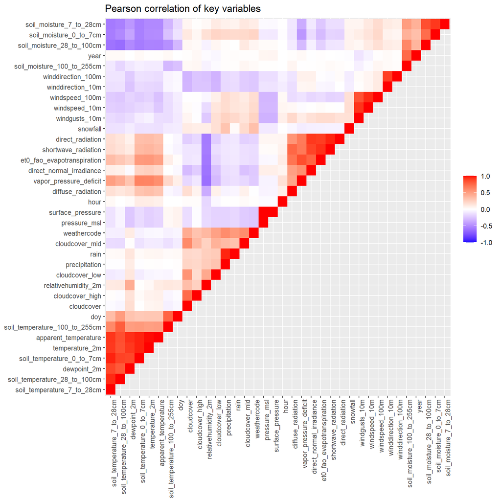

```r
corVarsTrainBOS <- makeHeatMap(allCity %>% filter(src=="Boston"), vecSelect=varsTrain, returnData=TRUE)
```

```r
corVarsTrainBOS %>% filter(Var1!=Var2) %>% arrange(desc(value)) %>% print(n=20)
```

```
## # A tibble: 630 × 3
##    Var1                         Var2                         value
##    <fct>                        <fct>                        <dbl>
##  1 surface_pressure             pressure_msl                 1.00
##  2 apparent_temperature         temperature_2m               0.993
##  3 temperature_2m               soil_temperature_0_to_7cm    0.965
##  4 apparent_temperature         soil_temperature_0_to_7cm    0.965
##  5 soil_temperature_0_to_7cm    soil_temperature_7_to_28cm   0.965
##  6 direct_radiation             shortwave_radiation          0.962
##  7 rain                         precipitation                0.959
##  8 soil_temperature_28_to_100cm soil_temperature_7_to_28cm   0.950
##  9 windspeed_100m               windspeed_10m                0.946
## 10 apparent_temperature         dewpoint_2m                  0.937
## 11 shortwave_radiation          et0_fao_evapotranspiration   0.935
## 12 windspeed_10m                windgusts_10m                0.927
## 13 apparent_temperature         soil_temperature_7_to_28cm   0.925
## 14 temperature_2m               dewpoint_2m                  0.917
## 15 direct_radiation             direct_normal_irradiance     0.916
## 16 soil_moisture_7_to_28cm      soil_moisture_0_to_7cm       0.915
## 17 temperature_2m               soil_temperature_7_to_28cm   0.914
## 18 direct_radiation             et0_fao_evapotranspiration   0.902
## 19 winddirection_100m           winddirection_10m            0.895
## 20 soil_temperature_0_to_7cm    soil_temperature_28_to_100cm 0.886
## # ℹ 610 more rows
```

Some variables, such as surface pressure vs. MSL pressure, are much differently correlated if controlling for city. Differences are explored:

```r
tstCorDelta <- corVarsTrain %>%
    mutate(v1=pmin(as.character(Var1), as.character(Var2)),
           v2=pmax(as.character(Var1), as.character(Var2))
           ) %>%
    select(v1, v2, value_all=value) %>%
    full_join(corVarsTrainBOS %>%
                  mutate(v1=pmin(as.character(Var1), as.character(Var2)),
                         v2=pmax(as.character(Var1), as.character(Var2))
                         ) %>%
                  select(v1, v2, value_bos=value),
              by=c("v1", "v2")
              ) %>%
    mutate(delta=value_bos-value_all)

tstCorDelta
```

```
## # A tibble: 666 × 5
##    v1                   v2                            value_all value_bos  delta
##    <chr>                <chr>                             <dbl>     <dbl>  <dbl>
##  1 dewpoint_2m          dewpoint_2m                     1          1      0
##  2 dewpoint_2m          soil_temperature_7_to_28cm      0.675      0.874  0.199
##  3 dewpoint_2m          soil_temperature_28_to_100cm    0.630      0.807  0.177
##  4 dewpoint_2m          soil_temperature_0_to_7cm       0.623      0.875  0.252
##  5 dewpoint_2m          temperature_2m                  0.691      0.917  0.226
##  6 apparent_temperature dewpoint_2m                     0.785      0.937  0.152
##  7 dewpoint_2m          soil_temperature_100_to_255cm   0.448      0.505  0.0567
##  8 dewpoint_2m          doy                             0.185      0.312  0.127
##  9 dewpoint_2m          hour                            0.00764    0.0203 0.0127
## 10 dewpoint_2m          vapor_pressure_deficit         -0.0678     0.305  0.373
## # ℹ 656 more rows
```

```r
tstCorDelta %>% arrange(delta) %>% head(20)
```

```
## # A tibble: 20 × 5
##    v1                         v2                      value_all value_bos  delta
##    <chr>                      <chr>                       <dbl>     <dbl>  <dbl>
##  1 relativehumidity_2m        surface_pressure           0.578   -0.160   -0.738
##  2 soil_moisture_0_to_7cm     surface_pressure           0.594   -0.0914  -0.685
##  3 soil_moisture_7_to_28cm    surface_pressure           0.586   -0.0240  -0.610
##  4 dewpoint_2m                surface_pressure           0.364   -0.237   -0.601
##  5 soil_moisture_100_to_255cm surface_pressure           0.602    0.00609 -0.596
##  6 soil_moisture_28_to_100cm  surface_pressure           0.588    0.0215  -0.566
##  7 surface_pressure           windspeed_100m             0.247   -0.311   -0.558
##  8 dewpoint_2m                soil_moisture_28_to_10…    0.0416  -0.508   -0.549
##  9 surface_pressure           windspeed_10m              0.195   -0.304   -0.498
## 10 dewpoint_2m                soil_moisture_7_to_28cm    0.0435  -0.448   -0.491
## 11 surface_pressure           windgusts_10m              0.133   -0.332   -0.465
## 12 dewpoint_2m                soil_moisture_0_to_7cm     0.0722  -0.393   -0.465
## 13 relativehumidity_2m        soil_moisture_28_to_10…    0.401   -0.0532  -0.454
## 14 relativehumidity_2m        soil_moisture_100_to_2…    0.374   -0.0545  -0.429
## 15 cloudcover                 surface_pressure           0.279   -0.144   -0.423
## 16 relativehumidity_2m        soil_moisture_7_to_28cm    0.441    0.0357  -0.406
## 17 soil_moisture_0_to_7cm     soil_moisture_100_to_2…    0.796    0.402   -0.393
## 18 cloudcover_low             surface_pressure           0.197   -0.186   -0.383
## 19 surface_pressure           weathercode                0.140   -0.240   -0.380
## 20 cloudcover_mid             surface_pressure           0.142   -0.221   -0.362
```

```r
tstCorDelta %>% arrange(desc(delta)) %>% head(20)
```

```
## # A tibble: 20 × 5
##    v1                         v2                       value_all value_bos delta
##    <chr>                      <chr>                        <dbl>     <dbl> <dbl>
##  1 soil_moisture_100_to_255cm year                        0.0387   0.739   0.701
##  2 pressure_msl               surface_pressure            0.401    1.00    0.599
##  3 soil_moisture_28_to_100cm  year                       -0.0677   0.386   0.454
##  4 soil_moisture_7_to_28cm    year                       -0.0426   0.406   0.449
##  5 surface_pressure           vapor_pressure_deficit     -0.493   -0.0499  0.443
##  6 dewpoint_2m                vapor_pressure_deficit     -0.0678   0.305   0.373
##  7 soil_moisture_100_to_255cm vapor_pressure_deficit     -0.337   -0.00259 0.334
##  8 soil_moisture_0_to_7cm     year                        0.0110   0.334   0.323
##  9 doy                        soil_temperature_100_to…    0.453    0.764   0.311
## 10 relativehumidity_2m        soil_temperature_0_to_7…   -0.253    0.00738 0.260
## 11 dewpoint_2m                soil_temperature_0_to_7…    0.623    0.875   0.252
## 12 relativehumidity_2m        soil_temperature_28_to_…   -0.133    0.116   0.249
## 13 relativehumidity_2m        temperature_2m             -0.213    0.0356  0.249
## 14 relativehumidity_2m        soil_temperature_7_to_2…   -0.139    0.109   0.247
## 15 relativehumidity_2m        soil_temperature_100_to…   -0.120    0.123   0.243
## 16 pressure_msl               vapor_pressure_deficit     -0.292   -0.0521  0.240
## 17 dewpoint_2m                temperature_2m              0.691    0.917   0.226
## 18 cloudcover                 temperature_2m             -0.162    0.0534  0.215
## 19 direct_normal_irradiance   surface_pressure           -0.118    0.0838  0.201
## 20 dewpoint_2m                soil_temperature_7_to_2…    0.675    0.874   0.199
```

The process is repeated, using an aggregation of correlations in each of the seven cities:

```r
keyCities <- allCity %>% pull(src) %>% unique()
keyCities
```

```
## [1] "NYC"     "LA"      "Chicago" "Houston" "Vegas"   "Miami"   "Boston"
```

```r
corVarsTrainEach <- keyCities %>%
    map_dfr(.f=function(x) makeHeatMap(allCity %>% filter(src==x),
                                       vecSelect=varsTrain[!varsTrain %in% ifelse(x=="Miami", "snowfall", "")],
                                       returnData=TRUE,
                                       plotMap=FALSE
                                       ) %>%
                mutate(v1=pmin(as.character(Var1), as.character(Var2)),
                       v2=pmax(as.character(Var1), as.character(Var2))
                       ) %>%
                select(v1, v2, value), .id="src") %>%
    mutate(city=keyCities[as.integer(src)]) %>%
    select(src, city, everything())

corVarsTrainEach
```

```
## # A tibble: 4,626 × 5
##    src   city  v1                            v2                           value
##    <chr> <chr> <chr>                         <chr>                        <dbl>
##  1 1     NYC   soil_temperature_7_to_28cm    soil_temperature_7_to_28cm  1
##  2 1     NYC   soil_temperature_28_to_100cm  soil_temperature_7_to_28cm  0.952
##  3 1     NYC   dewpoint_2m                   soil_temperature_7_to_28cm  0.883
##  4 1     NYC   soil_temperature_0_to_7cm     soil_temperature_7_to_28cm  0.954
##  5 1     NYC   soil_temperature_7_to_28cm    temperature_2m              0.932
##  6 1     NYC   apparent_temperature          soil_temperature_7_to_28cm  0.937
##  7 1     NYC   soil_temperature_100_to_255cm soil_temperature_7_to_28cm  0.584
##  8 1     NYC   doy                           soil_temperature_7_to_28cm  0.360
##  9 1     NYC   cloudcover_mid                soil_temperature_7_to_28cm -0.100
## 10 1     NYC   cloudcover_high               soil_temperature_7_to_28cm  0.0134
## # ℹ 4,616 more rows
```

```r
corVarsTrainEach %>%
    arrange(desc(value)) %>%
    filter(v1!=v2) %>%
    slice(1:15, (nrow(.)-14):nrow(.)) %>%
    print(n=30)
```

```
## # A tibble: 30 × 5
##    src   city    v1                         v2                             value
##    <chr> <chr>   <chr>                      <chr>                          <dbl>
##  1 6     Miami   precipitation              rain                           1
##  2 6     Miami   pressure_msl               surface_pressure               1.00
##  3 7     Boston  pressure_msl               surface_pressure               1.00
##  4 2     LA      precipitation              rain                           1.00
##  5 4     Houston pressure_msl               surface_pressure               1.00
##  6 4     Houston precipitation              rain                           1.00
##  7 1     NYC     pressure_msl               surface_pressure               1.00
##  8 5     Vegas   precipitation              rain                           0.999
##  9 3     Chicago pressure_msl               surface_pressure               0.994
## 10 1     NYC     apparent_temperature       temperature_2m                 0.993
## 11 3     Chicago apparent_temperature       temperature_2m                 0.993
## 12 7     Boston  apparent_temperature       temperature_2m                 0.993
```

[output cut: 18 more lines]

Comparison of aggregated individual city correlations to the overall correlations:

```r
corVarsTrainDelta <- corVarsTrain %>%
    mutate(v1=pmin(as.character(Var1), as.character(Var2)),
           v2=pmax(as.character(Var1), as.character(Var2))
    ) %>%
    select(v1, v2, value_all=value) %>%
    full_join(corVarsTrainEach %>%
                  group_by(v1, v2) %>%
                  summarize(value=mean(value), .groups="drop"),
              by=c("v1", "v2")) %>%
    mutate(delta=value-value_all)

corVarsTrainDelta %>%
    arrange(delta) %>%
    slice(1:15, (nrow(.)-14):nrow(.)) %>%
    print(n=30)
```

```
## # A tibble: 30 × 5
##    v1                         v2                       value_all    value  delta
##    <chr>                      <chr>                        <dbl>    <dbl>  <dbl>
##  1 relativehumidity_2m        surface_pressure            0.578  -0.178   -0.756
##  2 dewpoint_2m                surface_pressure            0.364  -0.371   -0.735
##  3 soil_moisture_100_to_255cm soil_moisture_7_to_28cm     0.824   0.156   -0.668
##  4 soil_moisture_0_to_7cm     soil_moisture_100_to_25…    0.796   0.138   -0.658
##  5 soil_moisture_0_to_7cm     surface_pressure            0.594  -0.0212  -0.615
##  6 soil_moisture_100_to_255cm surface_pressure            0.602  -0.00359 -0.606
##  7 soil_moisture_100_to_255cm soil_moisture_28_to_100…    0.859   0.283   -0.576
##  8 soil_moisture_7_to_28cm    surface_pressure            0.586   0.0143  -0.572
##  9 soil_moisture_28_to_100cm  surface_pressure            0.588   0.0277  -0.560
## 10 cloudcover                 surface_pressure            0.279  -0.138   -0.417
## 11 surface_pressure           windspeed_100m              0.247  -0.165   -0.412
## 12 relativehumidity_2m        soil_moisture_100_to_25…    0.374  -0.00330 -0.378
```

[output cut: 18 more lines]

Differences by variable are explored:

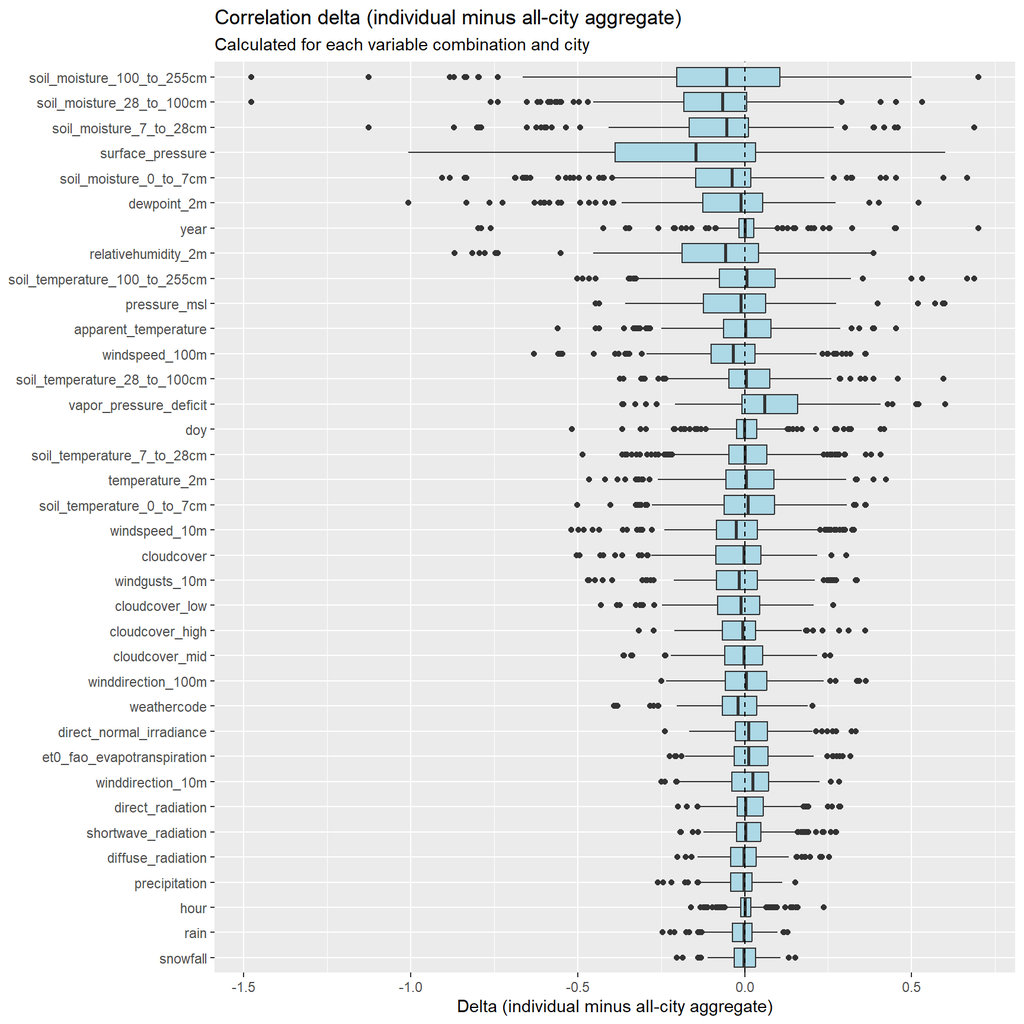

```r
corVarsTrain %>%
    mutate(v1=pmin(as.character(Var1), as.character(Var2)),
           v2=pmax(as.character(Var1), as.character(Var2))
    ) %>%
    select(v1, v2, value_all=value) %>%
    full_join(corVarsTrainEach, by=c("v1", "v2")) %>%
    mutate(delta=value-value_all) %>%
    filter(v1!=v2) %>%
    select(city, v1, v2, delta) %>%
    bind_rows(., ., .id="src") %>%
    mutate(vrbl=case_when(src=="1"~v1, src=="2"~v2, TRUE~NA)) %>%
    ggplot(aes(x=fct_reorder(vrbl, delta, .fun=function(x) diff(range(x))), y=delta)) +
    geom_boxplot(fill="lightblue") +
    coord_flip() +
    geom_hline(yintercept=0, color="black", lty=2) +
    labs(title="Correlation delta (individual minus all-city aggregate)",
         x=NULL,
         y="Delta (individual minus all-city aggregate)",
         subtitle="Calculated for each variable combination and city"
         )
```

Soil moisture, surface pressure, and dewpoint are among the variables with the highest changes in correlation when calculated n individual cities and the all-city aggregate

An example Simpson’s paradox is MSL pressure vs. surface pressure:

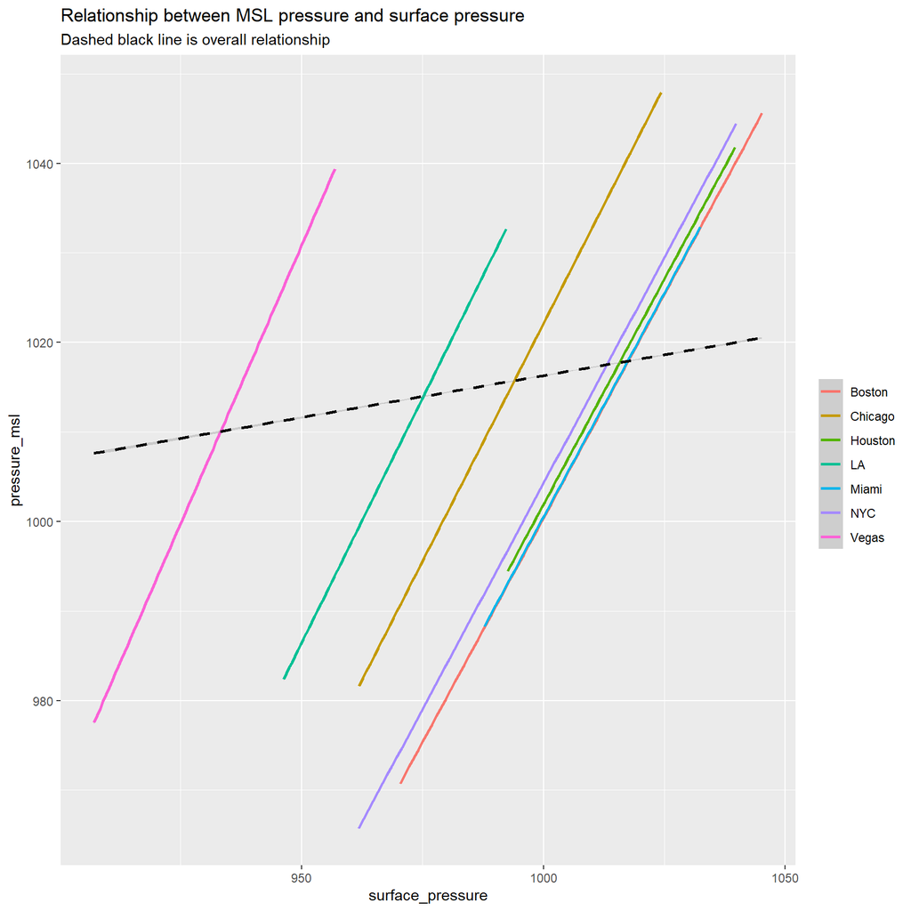

```r
allCity %>%
    count(src, surface_pressure, pressure_msl) %>%
    ggplot(aes(x=surface_pressure, pressure_msl)) +
    geom_smooth(aes(weight=n, color=src), method="lm") +
    geom_smooth(method="lm", lty=2, aes(weight=n), color="black") +
    labs(title="Relationship between MSL pressure and surface pressure",
         subtitle="Dashed black line is overall relationship"
         ) +
    scale_color_discrete(NULL)
```

The process is converted to functional form:

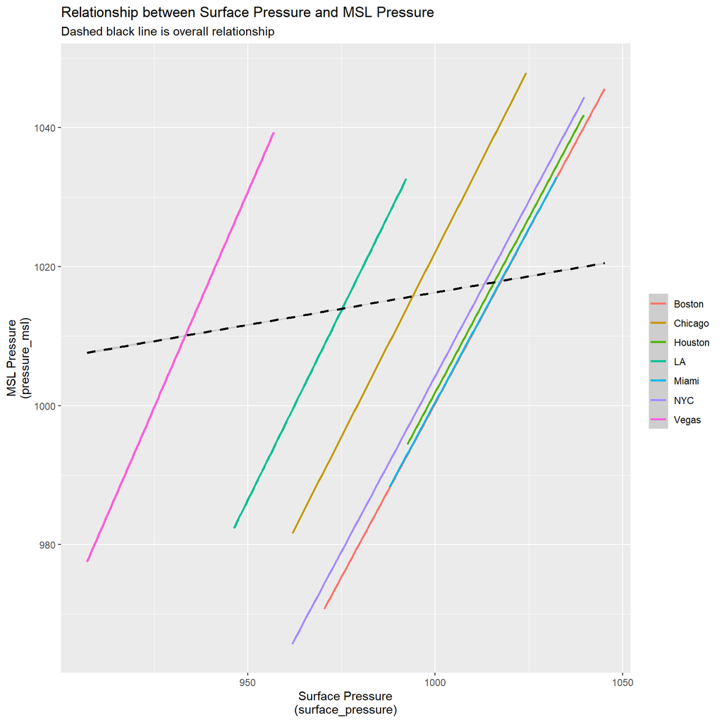

```r
tmpSmoothPlot <- function(df, x, y, xName=x, yName=y, printPlot=TRUE, returnPlot=!isTRUE(printPlot)) {

    # FUNCTION ARGUMENTS:
    # df: the data frame
    # x: x variable
    # y: y variable
    # xName: name to describe x variable
    # yName: name to describe y variable
    # printPlot: boolean, should plot be printed?
    # returnPlot: boolean, should plot object be returned?

    p1 <- df %>%
        select(src, all_of(c(x, y))) %>%
        purrr::set_names(c("src", "x1", "y1")) %>%
        count(src, x1, y1) %>%
        ggplot(aes(x=x1, y=y1)) +
        geom_smooth(aes(weight=n, color=src), method="lm") +
        geom_smooth(method="lm", lty=2, aes(weight=n), color="black") +
        labs(title=paste0("Relationship between ", xName, " and ", yName),
             subtitle="Dashed black line is overall relationship",
             y=if(y!=yName) paste0(yName, "\n(", y, ")") else y,
             x=if(x!=xName) paste0(xName, "\n(", x, ")") else x
             ) +
    scale_color_discrete(NULL)

    # Print plot if requested
    if(isTRUE(printPlot)) print(p1)

    # Return plot if requested
    if(isTRUE(returnPlot)) return(p1)

}

# Example function call
tmpSmoothPlot(allCity,
              x="surface_pressure",
              y="pressure_msl",
              yName="MSL Pressure",
              xName="Surface Pressure"
              )
```

The function is tested on two additional sets of metrics:

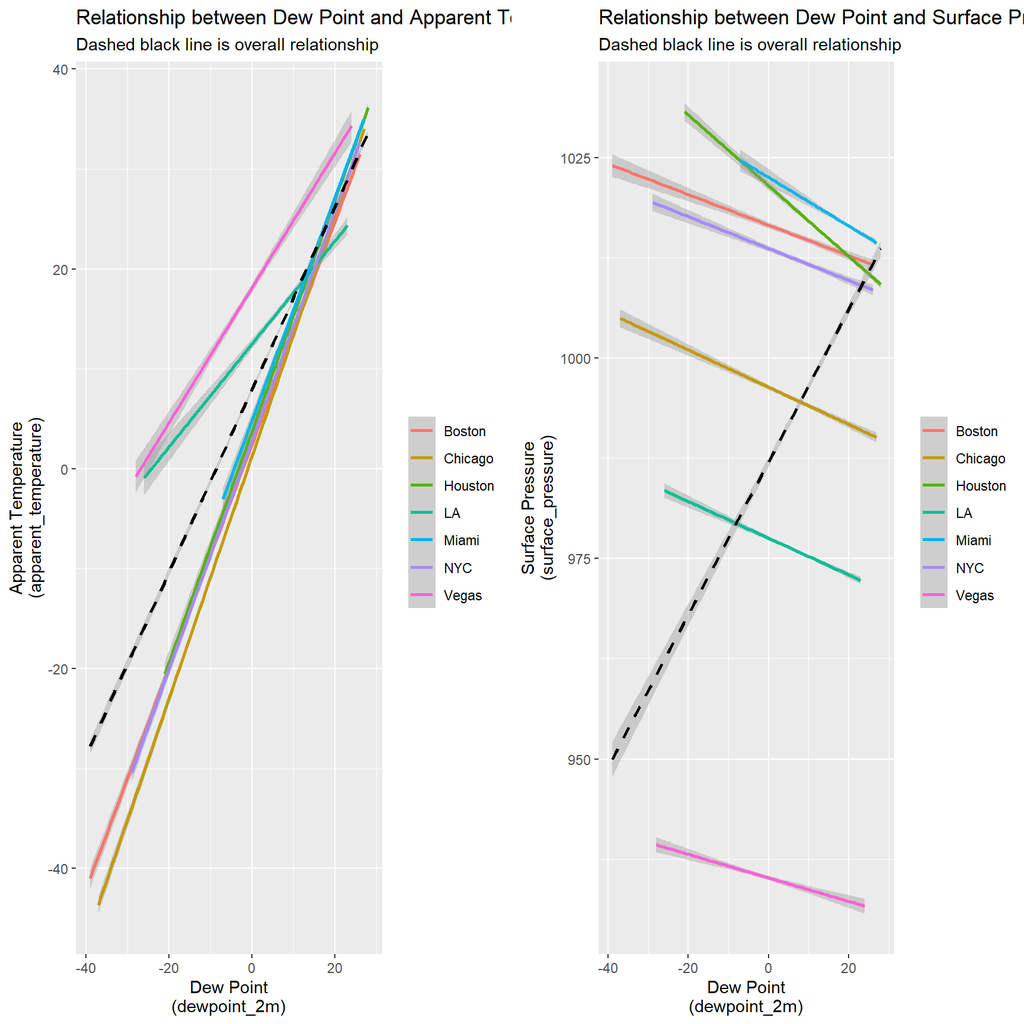

```r
gridExtra::grid.arrange(tmpSmoothPlot(allCity %>%
                                          mutate(across(c("apparent_temperature", "dewpoint_2m"),
                                                        .fns=function(x) round(x)
                                                        )
                                                 ),
                                      x="dewpoint_2m",
                                      y="apparent_temperature",
                                      xName="Dew Point",
                                      yName="Apparent Temperature",
                                      printPlot=FALSE
                                      ),
                        tmpSmoothPlot(allCity %>%
                                          mutate(across(c("surface_pressure", "dewpoint_2m"),
                                                        .fns=function(x) round(x)
                                                        )
                                                 ),
                                      x="dewpoint_2m",
                                      y="surface_pressure",
                                      xName="Dew Point",
                                      yName="Surface Pressure",
                                      printPlot=FALSE
                                      ),
                        nrow=1
                        )
```

The function is updated to allow for rounding:

```r
tmpSmoothPlot <- function(df,
                          x,
                          y,
                          xRound=NULL,
                          yRound=NULL,
                          xName=x,
                          yName=y,
                          printPlot=TRUE,
                          returnPlot=!isTRUE(printPlot)
                          ) {

    # FUNCTION ARGUMENTS:
    # df: the data frame
    # x: x variable
    # y: y variable
    # {x,y}Round: rounding to apply to vector {x,y} using function autoRound()
    #             NULL means no rounding (default)
    #             -1L means make an estimate based on data (around 100 buckets created)
    #             a positive float or integer means round everything to the nearest multiple
    # xName: name to describe x variable
    # yName: name to describe y variable
    # printPlot: boolean, should plot be printed?
    # returnPlot: boolean, should plot object be returned?

    p1 <- df %>%
        select(src, all_of(c(x, y))) %>%
        purrr::set_names(c("src", "x1", "y1")) %>%
        mutate(x1=autoRound(x1, rndTo=xRound),
               y1=autoRound(y1, rndTo=yRound)
               ) %>%
        count(src, x1, y1) %>%
        ggplot(aes(x=x1, y=y1)) +
        geom_smooth(aes(weight=n, color=src), method="lm") +
        geom_smooth(method="lm", lty=2, aes(weight=n), color="black") +
        labs(title=paste0("Relationship between ", xName, " and ", yName),
             subtitle="Dashed black line is overall relationship",
             y=if(y!=yName) paste0(yName, "\n(", y, ")") else y,
             x=if(x!=xName) paste0(xName, "\n(", x, ")") else x
             ) +
    scale_color_discrete(NULL)

    # Print plot if requested
    if(isTRUE(printPlot)) print(p1)

    # Return plot if requested
    if(isTRUE(returnPlot)) return(p1)

}
```

The updated function is tested on elements with many buckets:

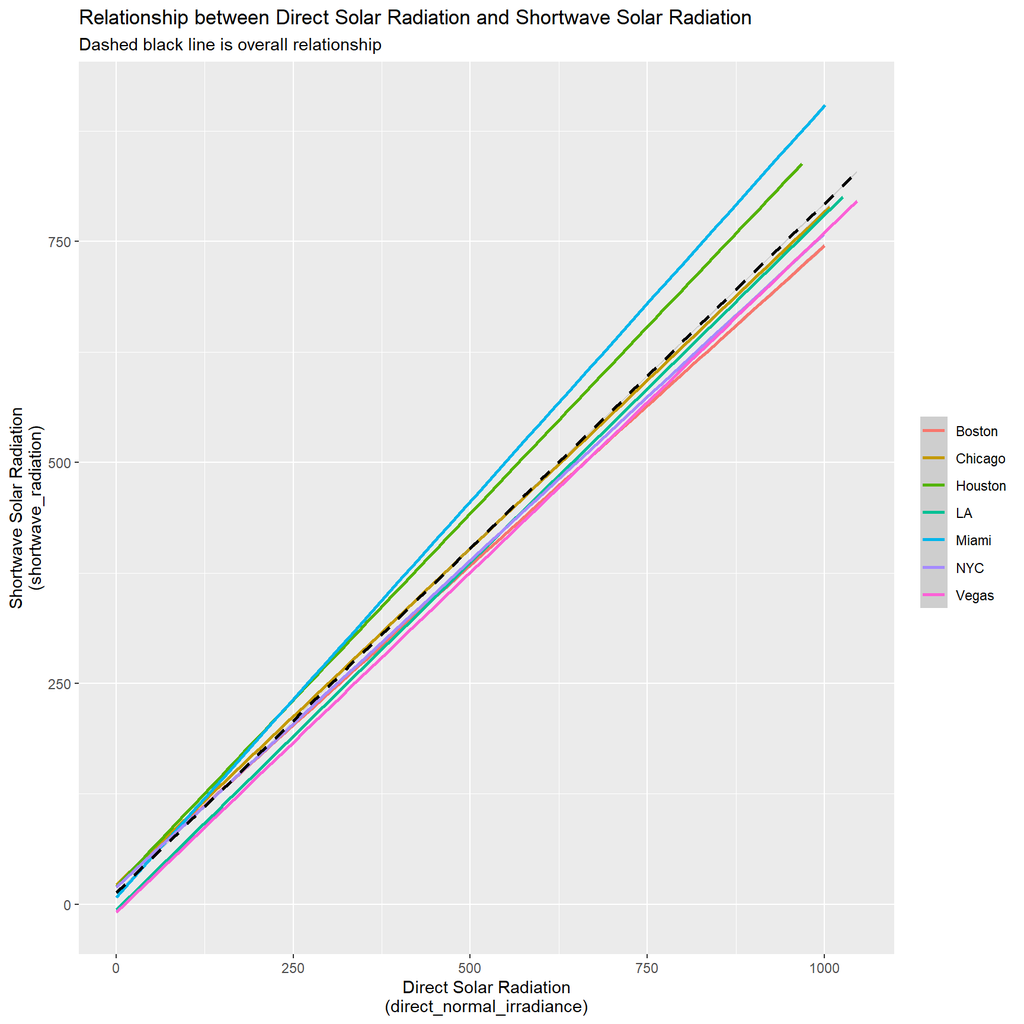

```
##    user  system elapsed
##    5.05    0.28    5.39
```

```r
# Example function call (no rounding)
t0 <- Sys.time()
system.time(
    tmpSmoothPlot(allCity,
                  x="direct_normal_irradiance",
                  y="shortwave_radiation",
                  xName="Direct Solar Radiation",
                  yName="Shortwave Solar Radiation"
                  )
    )
```

```r
Sys.time() - t0
```

```
## Time difference of 5.616624 secs
```

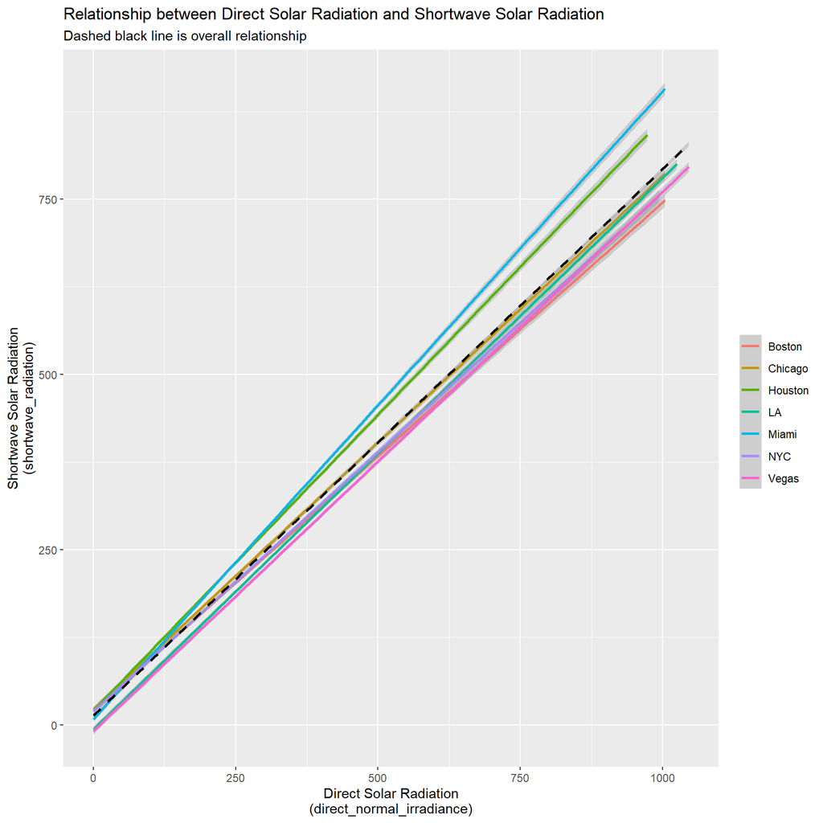

```
##    user  system elapsed
##    0.94    0.16    1.09
```

```r
# Example function call (rounding)
t0 <- Sys.time()
system.time(
    tmpSmoothPlot(allCity,
                  x="direct_normal_irradiance",
                  y="shortwave_radiation",
                  xRound=-1L,
                  yRound=-1L,
                  xName="Direct Solar Radiation",
                  yName="Shortwave Solar Radiation"
                  )
    )
```

```r
Sys.time() - t0
```

```
## Time difference of 1.337907 secs
```

A simple model is run to predict surface pressure as a function of dewpoint, without considering location:

```r
# Create model
tstLM <- allCity %>%
    select(dewpoint_2m, surface_pressure) %>%
    lm(surface_pressure ~ dewpoint_2m, data=.)

# Summary
summary(tstLM)
```

```
##
## Call:
## lm(formula = surface_pressure ~ dewpoint_2m, data = .)
##
## Residuals:
##     Min      1Q  Median      3Q     Max
## -82.042 -15.314   5.729  17.119  83.092
##
## Coefficients:
##              Estimate Std. Error t value Pr(>|t|)
## (Intercept) 9.871e+02  3.631e-02 27182.2   <2e-16 ***
## dewpoint_2m 9.507e-01  2.632e-03   361.2   <2e-16 ***
## ---
## Signif. codes:  0 '***' 0.001 '**' 0.01 '*' 0.05 '.' 0.1 ' ' 1
##
## Residual standard error: 26.72 on 854206 degrees of freedom
## Multiple R-squared:  0.1325, Adjusted R-squared:  0.1325
## F-statistic: 1.305e+05 on 1 and 854206 DF,  p-value: < 2.2e-16
```

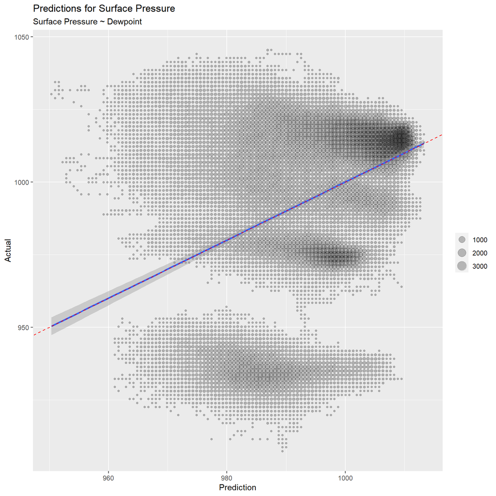

```r
# Review of predictions
allCity %>%
    select(src, dewpoint_2m, surface_pressure) %>%
    mutate(pred=predict(tstLM, newdata=.)) %>%
    mutate(across(c(surface_pressure, pred), .fns=function(x) autoRound(x))) %>%
    count(surface_pressure, pred) %>%
    ggplot(aes(x=pred, y=surface_pressure)) +
    geom_point(aes(size=n), alpha=0.25) +
    geom_smooth(aes(weight=n), method="lm") +
    geom_abline(slope=1, intercept=0, lty=2, color="red") +
    labs(x="Prediction",
         y="Actual",
         title="Predictions for Surface Pressure",
         subtitle="Surface Pressure ~ Dewpoint"
         ) +
    scale_size_continuous(NULL)
```

The model is updated to predict surface pressure as a function of dewpoint, considering location:

```r
# Create model
tstLM_002 <- allCity %>%
    select(dewpoint_2m, surface_pressure, src) %>%
    lm(surface_pressure ~ dewpoint_2m:src + src, data=.)

# Summary
summary(tstLM_002)
```

```
##
## Call:
## lm(formula = surface_pressure ~ dewpoint_2m:src + src, data = .)
##
## Residuals:
##     Min      1Q  Median      3Q     Max
## -48.856  -2.901   0.233   3.277  28.618
##
## Coefficients:
##                          Estimate Std. Error  t value Pr(>|t|)
## (Intercept)             1.017e+03  1.844e-02 55129.10   <2e-16 ***
## srcChicago             -2.021e+01  2.594e-02  -779.18   <2e-16 ***
## srcHouston              4.918e+00  4.032e-02   121.98   <2e-16 ***
## srcLA                  -3.904e+01  2.910e-02 -1341.57   <2e-16 ***
## srcMiami                5.985e+00  7.381e-02    81.09   <2e-16 ***
## srcNYC                 -2.917e+00  2.700e-02  -108.04   <2e-16 ***
## srcVegas               -8.141e+01  2.487e-02 -3273.38   <2e-16 ***
## dewpoint_2m:srcBoston  -1.907e-01  1.561e-03  -122.19   <2e-16 ***
## dewpoint_2m:srcChicago -2.323e-01  1.493e-03  -155.62   <2e-16 ***
## dewpoint_2m:srcHouston -4.411e-01  2.017e-03  -218.66   <2e-16 ***
## dewpoint_2m:srcLA      -2.287e-01  2.261e-03  -101.17   <2e-16 ***
## dewpoint_2m:srcMiami   -3.044e-01  3.512e-03   -86.66   <2e-16 ***
## dewpoint_2m:srcNYC     -1.990e-01  1.607e-03  -123.81   <2e-16 ***
## dewpoint_2m:srcVegas   -1.471e-01  2.120e-03   -69.39   <2e-16 ***
## ---
## Signif. codes:  0 '***' 0.001 '**' 0.01 '*' 0.05 '.' 0.1 ' ' 1
##
## Residual standard error: 5.725 on 854194 degrees of freedom
## Multiple R-squared:  0.9602, Adjusted R-squared:  0.9602
## F-statistic: 1.585e+06 on 13 and 854194 DF,  p-value: < 2.2e-16
```

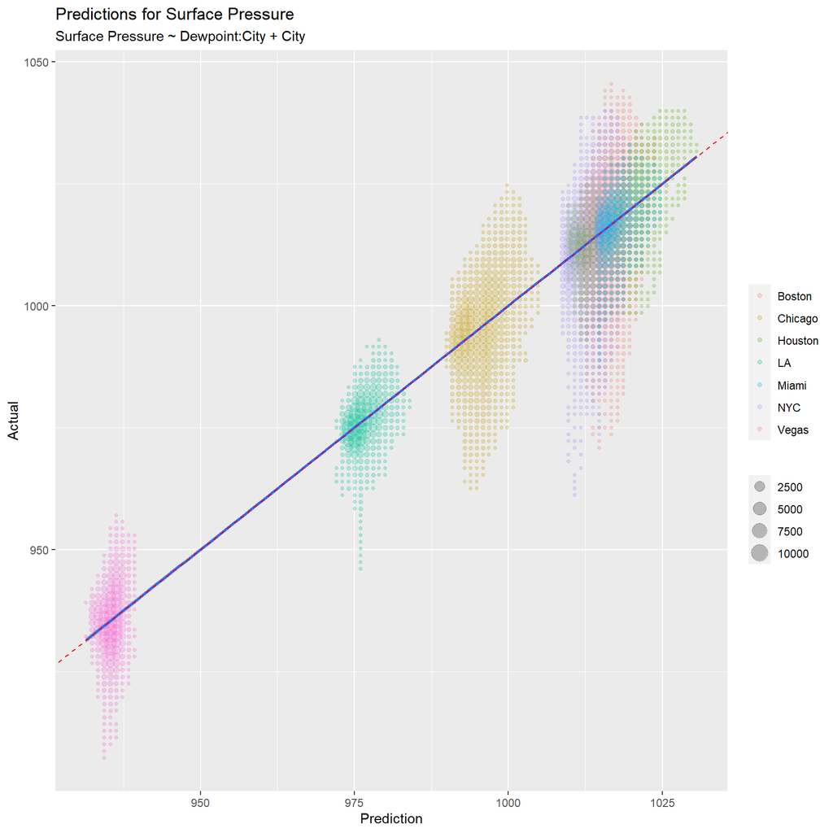

```r
# Review of predictions
allCity %>%
    select(src, dewpoint_2m, surface_pressure) %>%
    mutate(pred=predict(tstLM_002, newdata=.)) %>%
    mutate(across(c(surface_pressure, pred), .fns=function(x) autoRound(x))) %>%
    count(src, surface_pressure, pred) %>%
    ggplot(aes(x=pred, y=surface_pressure)) +
    geom_point(aes(size=n, color=src), alpha=0.25) +
    geom_smooth(aes(weight=n), method="lm") +
    geom_abline(slope=1, intercept=0, lty=2, color="red") +
    labs(x="Prediction",
         y="Actual",
         title="Predictions for Surface Pressure",
         subtitle="Surface Pressure ~ Dewpoint:City + City"
         ) +
    scale_size_continuous(NULL) +
    scale_color_discrete(NULL)
```

Long term daily data is downloaded for Atlanta:

```r
# Daily data download for Atlanta, GA
testURLDaily <- helperOpenMeteoURL(cityName="Atlanta GA",
                                   dailyIndices=1:nrow(tblMetricsDaily),
                                   startDate="1960-01-01",
                                   endDate="2023-12-31",
                                   tz="US/Eastern"
                                   )
```

```
##
## Daily metrics created from indices: weathercode,temperature_2m_max,temperature_2m_min,apparent_temperature_max,apparent_temperature_min,precipitation_sum,rain_sum,snowfall_sum,precipitation_hours,sunrise,sunset,windspeed_10m_max,windgusts_10m_max,winddirection_10m_dominant,shortwave_radiation_sum…
```

```r
testURLDaily
```

```
## [1] "https://archive-api.open-meteo.com/v1/archive?latitude=33.76&longitude=-84.42&start_date=1960-01-01&end_date=2023-12-31&daily=weathercode,temperature_2m_max,temperature_2m_min,apparent_temperature_max,apparent_temperature_min,precipitation_sum,rain_sum,snowfall_sum,precipitation_hours,sunris…
```

```r
# Download file
if(!file.exists("testOM_daily_atl.json")) {
    fileDownload(fileName="testOM_daily_atl.json", url=testURLDaily)
} else {
    cat("\nFile testOM_daily_atl.json already exists, skipping download\n")
}
```

```
##
## File testOM_daily_atl.json already exists, skipping download
```

The daily dataset is loaded:

```r
# Read daily JSON file
atlOMDaily <- formatOpenMeteoJSON("testOM_daily_atl.json")
```

```
##
## Objects in JSON include: latitude, longitude, generationtime_ms, utc_offset_seconds, timezone, timezone_abbreviation, elevation, daily_units, daily
##
## $tblDaily
## # A tibble: 23,376 × 18
##    date       time       weathercode temperature_2m_max temperature_2m_min
##    <date>     <chr>            <int>              <dbl>              <dbl>
##  1 1960-01-01 1960-01-01          71                2.6                0.1
##  2 1960-01-02 1960-01-02          61               11.4                1.5
##  3 1960-01-03 1960-01-03          63               14.7                2
##  4 1960-01-04 1960-01-04          53                7.3               -0.1
##  5 1960-01-05 1960-01-05          51                7.1                0.2
##  6 1960-01-06 1960-01-06          53                7.3                4.5
##  7 1960-01-07 1960-01-07          61                7.4                3.1
##  8 1960-01-08 1960-01-08           2               10.7                0.4
##  9 1960-01-09 1960-01-09           3               15                 -0.8
## 10 1960-01-10 1960-01-10           3               17.5                4
## # ℹ 23,366 more rows
## # ℹ 13 more variables: apparent_temperature_max <dbl>,
## #   apparent_temperature_min <dbl>, precipitation_sum <dbl>, rain_sum <dbl>,
## #   snowfall_sum <dbl>, precipitation_hours <dbl>, sunrise <chr>, sunset <chr>,
## #   windspeed_10m_max <dbl>, windgusts_10m_max <dbl>,
## #   winddirection_10m_dominant <int>, shortwave_radiation_sum <dbl>,
## #   et0_fao_evapotranspiration <dbl>
##
## $tblHourly
## NULL
##
## $tblUnits
## # A tibble: 17 × 4
##    metricType  name                       value      description
##    <chr>       <chr>                      <chr>      <chr>
##  1 daily_units time                       "iso8601"  <NA>
##  2 daily_units weathercode                "wmo code" The most severe weather co…
##  3 daily_units temperature_2m_max         "deg C"    Maximum and minimum daily …
##  4 daily_units temperature_2m_min         "deg C"    Maximum and minimum daily …
##  5 daily_units apparent_temperature_max   "deg C"    Maximum and minimum daily …
##  6 daily_units apparent_temperature_min   "deg C"    Maximum and minimum daily …
##  7 daily_units precipitation_sum          "mm"       Sum of daily precipitation…
##  8 daily_units rain_sum                   "mm"       Sum of daily rain
```

[output cut: 10 more lines]

```
## $tblDescription
## # A tibble: 1 × 7
##   latitude longitude generationtime_ms utc_offset_seconds timezone
##      <dbl>     <dbl>             <dbl>              <int> <chr>
## 1     33.8     -84.4              388.             -18000 US/Eastern
## # ℹ 2 more variables: timezone_abbreviation <chr>, elevation <dbl>
##
##
## latitude: 33.77856
## longitude: -84.40299
## generationtime_ms: 388.082
## utc_offset_seconds: -18000
## timezone: US/Eastern
## timezone_abbreviation: EST
## elevation: 302
```

```r
# Sample records of tibble
atlOMDaily$tblDaily %>% glimpse()
```

```
## Rows: 23,376
## Columns: 18
## $ date                       <date> 1960-01-01, 1960-01-02, 1960-01-03, 1960-0…
## $ time                       <chr> "1960-01-01", "1960-01-02", "1960-01-03", "…
## $ weathercode                <int> 71, 61, 63, 53, 51, 53, 61, 2, 3, 3, 3, 3, …
## $ temperature_2m_max         <dbl> 2.6, 11.4, 14.7, 7.3, 7.1, 7.3, 7.4, 10.7, …
## $ temperature_2m_min         <dbl> 0.1, 1.5, 2.0, -0.1, 0.2, 4.5, 3.1, 0.4, -0…
## $ apparent_temperature_max   <dbl> -2.3, 9.2, 13.1, 2.8, 4.4, 6.1, 4.9, 6.9, 1…
## $ apparent_temperature_min   <dbl> -4.0, -3.1, -2.7, -4.7, -3.3, 1.4, -0.5, -4…
## $ precipitation_sum          <dbl> 3.0, 7.8, 7.3, 1.1, 0.6, 5.8, 8.7, 0.0, 0.0…
## $ rain_sum                   <dbl> 2.5, 7.8, 7.3, 1.1, 0.6, 5.8, 8.7, 0.0, 0.0…
## $ snowfall_sum               <dbl> 0.35, 0.00, 0.00, 0.00, 0.00, 0.00, 0.00, 0…
## $ precipitation_hours        <dbl> 13, 21, 5, 3, 3, 17, 8, 0, 0, 0, 0, 0, 0, 5…
## $ sunrise                    <chr> "1960-01-01T07:42", "1960-01-02T07:42", "19…
## $ sunset                     <chr> "1960-01-01T17:39", "1960-01-02T17:40", "19…
## $ windspeed_10m_max          <dbl> 20.9, 18.7, 23.8, 15.5, 9.2, 11.4, 19.2, 17…
## $ windgusts_10m_max          <dbl> 39.6, 41.4, 56.2, 44.6, 33.1, 41.8, 39.2, 3…
## $ winddirection_10m_dominant <int> 90, 106, 295, 318, 2, 69, 288, 313, 140, 24…
## $ shortwave_radiation_sum    <dbl> 2.38, 1.83, 10.18, 9.37, 3.88, 1.77, 5.34, …
## $ et0_fao_evapotranspiration <dbl> 0.57, 0.38, 1.34, 1.36, 0.65, 0.33, 0.76, 1…
```

Variables are converted to proper data type:

```r
dfDailyATL <- atlOMDaily$tblDaily %>%
    mutate(weathercode=factor(weathercode),
           sunrise_chr=sunrise,
           sunset_chr=sunset,
           sunrise=lubridate::ymd_hm(sunrise),
           sunset=lubridate::ymd_hm(sunset),
           fct_winddir=factor(winddirection_10m_dominant)
           )
glimpse(dfDailyATL)
```

```
## Rows: 23,376
## Columns: 21
## $ date                       <date> 1960-01-01, 1960-01-02, 1960-01-03, 1960-0…
## $ time                       <chr> "1960-01-01", "1960-01-02", "1960-01-03", "…
## $ weathercode                <fct> 71, 61, 63, 53, 51, 53, 61, 2, 3, 3, 3, 3, …
## $ temperature_2m_max         <dbl> 2.6, 11.4, 14.7, 7.3, 7.1, 7.3, 7.4, 10.7, …
## $ temperature_2m_min         <dbl> 0.1, 1.5, 2.0, -0.1, 0.2, 4.5, 3.1, 0.4, -0…
## $ apparent_temperature_max   <dbl> -2.3, 9.2, 13.1, 2.8, 4.4, 6.1, 4.9, 6.9, 1…
## $ apparent_temperature_min   <dbl> -4.0, -3.1, -2.7, -4.7, -3.3, 1.4, -0.5, -4…
## $ precipitation_sum          <dbl> 3.0, 7.8, 7.3, 1.1, 0.6, 5.8, 8.7, 0.0, 0.0…
## $ rain_sum                   <dbl> 2.5, 7.8, 7.3, 1.1, 0.6, 5.8, 8.7, 0.0, 0.0…
## $ snowfall_sum               <dbl> 0.35, 0.00, 0.00, 0.00, 0.00, 0.00, 0.00, 0…
## $ precipitation_hours        <dbl> 13, 21, 5, 3, 3, 17, 8, 0, 0, 0, 0, 0, 0, 5…
## $ sunrise                    <dttm> 1960-01-01 07:42:00, 1960-01-02 07:42:00, …
## $ sunset                     <dttm> 1960-01-01 17:39:00, 1960-01-02 17:40:00, …
## $ windspeed_10m_max          <dbl> 20.9, 18.7, 23.8, 15.5, 9.2, 11.4, 19.2, 17…
## $ windgusts_10m_max          <dbl> 39.6, 41.4, 56.2, 44.6, 33.1, 41.8, 39.2, 3…
## $ winddirection_10m_dominant <int> 90, 106, 295, 318, 2, 69, 288, 313, 140, 24…
## $ shortwave_radiation_sum    <dbl> 2.38, 1.83, 10.18, 9.37, 3.88, 1.77, 5.34, …
## $ et0_fao_evapotranspiration <dbl> 0.57, 0.38, 1.34, 1.36, 0.65, 0.33, 0.76, 1…
## $ sunrise_chr                <chr> "1960-01-01T07:42", "1960-01-02T07:42", "19…
## $ sunset_chr                 <chr> "1960-01-01T17:39", "1960-01-02T17:40", "19…
## $ fct_winddir                <fct> 90, 106, 295, 318, 2, 69, 288, 313, 140, 24…
```

Averages by month for select continuous variables are plotted:

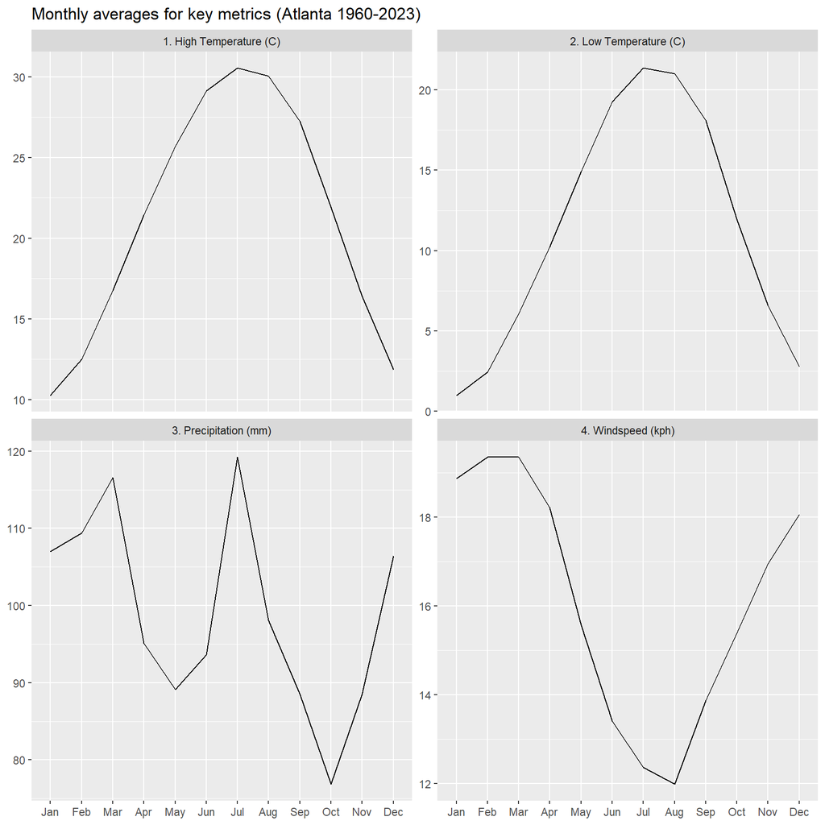

```r
tmpMapNames <- c("precipitation_sum"="3. Precipitation (mm)",
                 "windspeed_10m_max"="4. Windspeed (kph)",
                 "temperature_2m_max"="1. High Temperature (C)",
                 "temperature_2m_min"="2. Low Temperature (C)"
                 )

dfDailyATL %>%
    mutate(month=factor(month(date), levels=1:12, labels=month.abb), year=year(date)) %>%
    select(year, month, temperature_2m_max, temperature_2m_min, precipitation_sum, windspeed_10m_max) %>%
    group_by(year, month) %>%
    summarize(across(-c(precipitation_sum), .fns=mean),
              across(c(precipitation_sum), .fns=sum),
              .groups="drop"
              ) %>%
    group_by(month) %>%
    summarize(across(-c(year), .fns=mean)) %>%
    pivot_longer(-c(month)) %>%
    ggplot(aes(x=month, y=value)) +
    geom_line(aes(group=1)) +
    facet_wrap(~tmpMapNames[name], scales="free_y") +
    labs(x=NULL, y=NULL, title="Monthly averages for key metrics (Atlanta 1960-2023)")
```

Averages by month for select categorical variables are plotted:

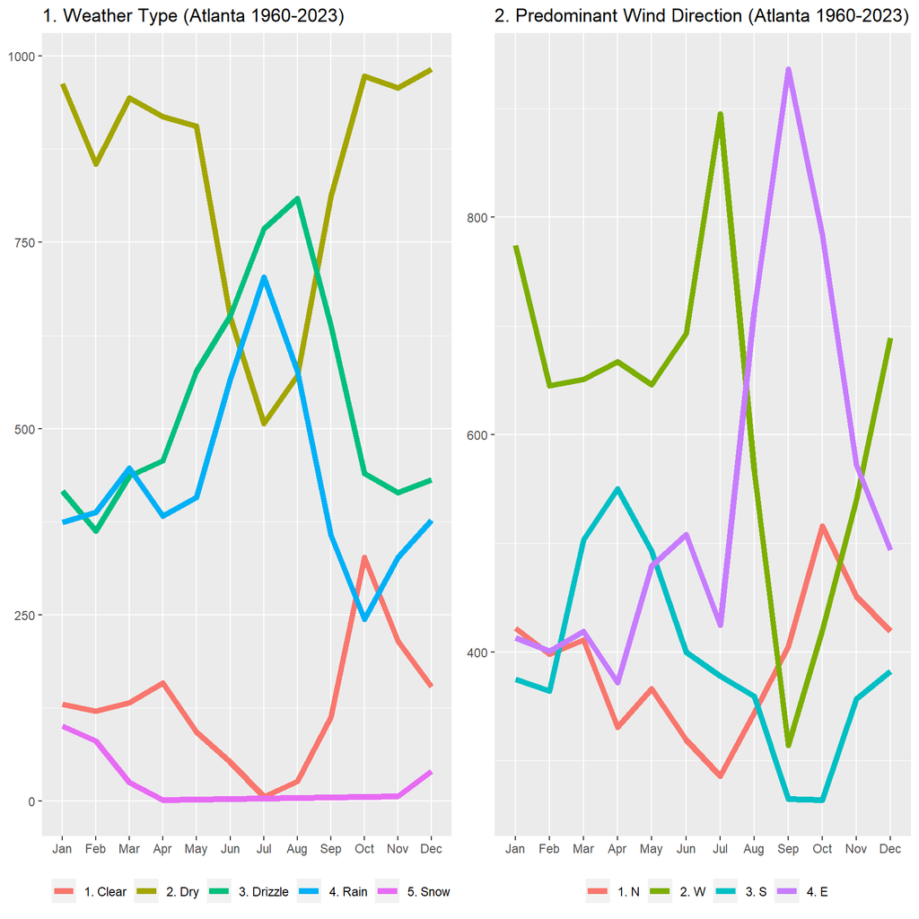

```r
tmpMapNames <- c("wc"="1. Weather Type",
                 "winddir"="2. Predominant Wind Direction"
                 )

tmpDFPlot <- dfDailyATL %>%
    mutate(month=factor(month(date), levels=1:12, labels=month.abb),
           year=year(date),
           winddir=case_when(winddirection_10m_dominant>360~"Invalid",
                             winddirection_10m_dominant>=315~"1. N",
                             winddirection_10m_dominant>=225~"2. W",
                             winddirection_10m_dominant>=135~"3. S",
                             winddirection_10m_dominant>=45~"4. E",
                             winddirection_10m_dominant>=0~"1. N",
                             TRUE~"Invalid"
                             ),
           wc=case_when(weathercode==0~"1. Clear",
                        weathercode %in% c(1, 2, 3)~"2. Dry",
                        weathercode %in% c(51, 53, 55)~"3. Drizzle",
                        weathercode %in% c(61, 63, 65)~"4. Rain",
                        weathercode %in% c(71, 73, 75)~"5. Snow",
                        TRUE~"Error"
                        )
           ) %>%
    select(month, wc, winddir) %>%
    pivot_longer(-c(month)) %>%
    count(month, name, value)

tmpPlotFN <- function(x) {
    p1 <- tmpDFPlot %>%
        filter(name==x) %>%
        ggplot(aes(x=month, y=n)) +
        geom_line(aes(group=value, color=value), lwd=2) +
        labs(x=NULL,
             y=NULL,
             title=paste0(tmpMapNames[x], " (Atlanta 1960-2023)")
             ) +
        scale_color_discrete(NULL) +
        theme(legend.position = "bottom")
    return(p1)
    }

gridExtra::grid.arrange(tmpPlotFN("wc"), tmpPlotFN("winddir"), nrow=1)
```

Averages by year for select variables are plotted:

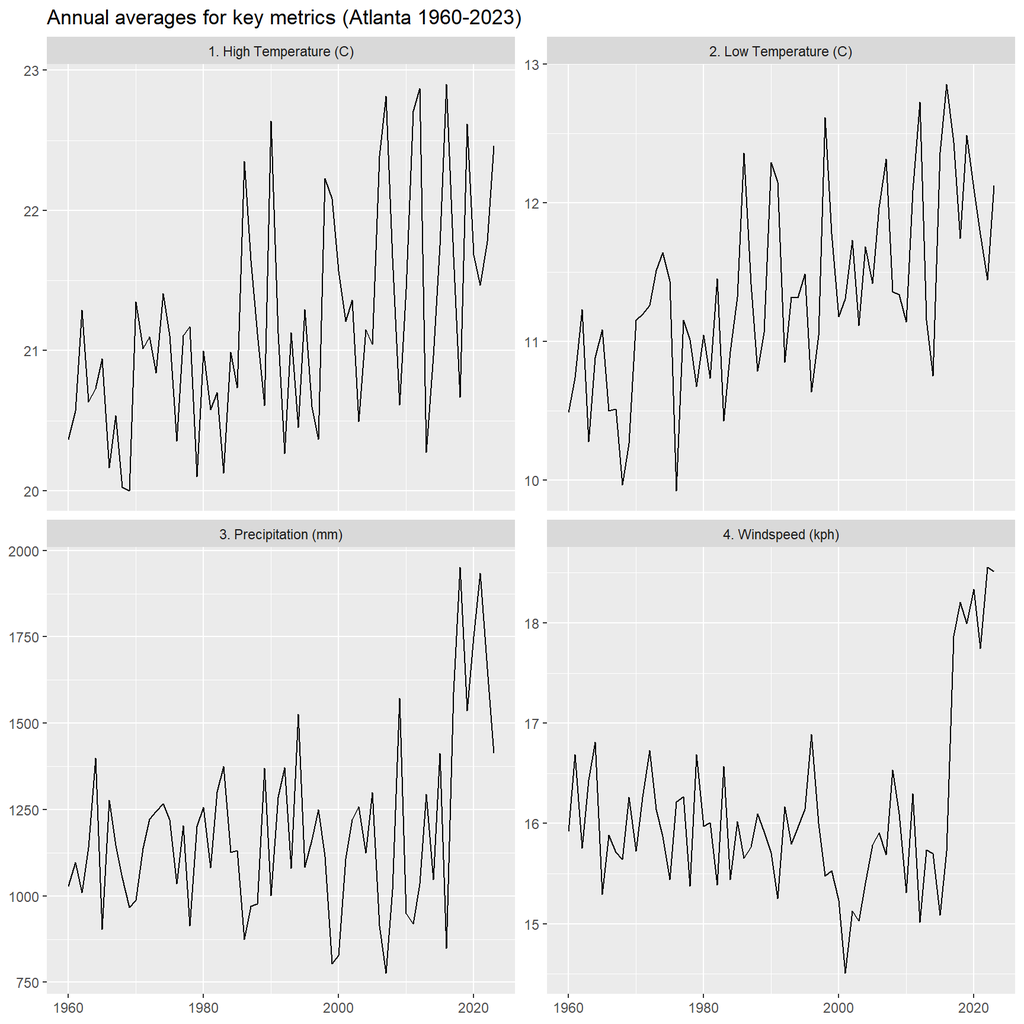

```r
tmpMapNames <- c("precipitation_sum"="3. Precipitation (mm)",
                 "windspeed_10m_max"="4. Windspeed (kph)",
                 "temperature_2m_max"="1. High Temperature (C)",
                 "temperature_2m_min"="2. Low Temperature (C)"
                 )

dfDailyATL %>%
    mutate(month=factor(month(date), levels=1:12, labels=month.abb), year=year(date)) %>%
    select(year, temperature_2m_max, temperature_2m_min, precipitation_sum, windspeed_10m_max) %>%
    group_by(year) %>%
    summarize(across(-c(precipitation_sum), .fns=mean),
              across(c(precipitation_sum), .fns=sum),
              .groups="drop"
              ) %>%
    pivot_longer(-c(year)) %>%
    ggplot(aes(x=year, y=value)) +
    geom_line(aes(group=1)) +
    facet_wrap(~tmpMapNames[name], scales="free_y") +
    labs(x=NULL, y=NULL, title="Annual averages for key metrics (Atlanta 1960-2023)")
```

Averages by year for select categorical variables are plotted:

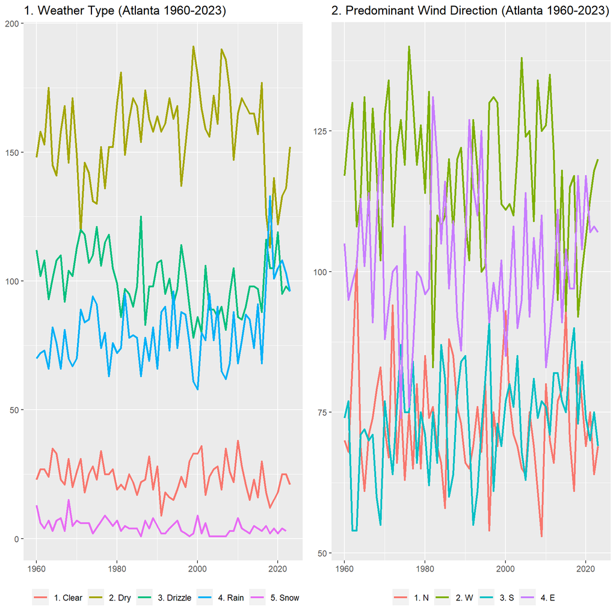

```r
tmpMapNames <- c("wc"="1. Weather Type",
                 "winddir"="2. Predominant Wind Direction"
                 )

tmpDFPlot <- dfDailyATL %>%
    mutate(month=factor(month(date), levels=1:12, labels=month.abb),
           year=year(date),
           winddir=case_when(winddirection_10m_dominant>360~"Invalid",
                             winddirection_10m_dominant>=315~"1. N",
                             winddirection_10m_dominant>=225~"2. W",
                             winddirection_10m_dominant>=135~"3. S",
                             winddirection_10m_dominant>=45~"4. E",
                             winddirection_10m_dominant>=0~"1. N",
                             TRUE~"Invalid"
                             ),
           wc=case_when(weathercode==0~"1. Clear",
                        weathercode %in% c(1, 2, 3)~"2. Dry",
                        weathercode %in% c(51, 53, 55)~"3. Drizzle",
                        weathercode %in% c(61, 63, 65)~"4. Rain",
                        weathercode %in% c(71, 73, 75)~"5. Snow",
                        TRUE~"Error"
                        )
           ) %>%
    select(year, wc, winddir) %>%
    pivot_longer(-c(year)) %>%
    count(year, name, value)

tmpPlotFN <- function(x) {
    p1 <- tmpDFPlot %>%
        filter(name==x) %>%
        ggplot(aes(x=year, y=n)) +
        geom_line(aes(group=value, color=value), lwd=1) +
        labs(x=NULL,
             y=NULL,
             title=paste0(tmpMapNames[x], " (Atlanta 1960-2023)")
             ) +
        scale_color_discrete(NULL) +
        theme(legend.position = "bottom")
    return(p1)
    }

gridExtra::grid.arrange(tmpPlotFN("wc"), tmpPlotFN("winddir"), nrow=1)
```

Boxplots for maximum windspeed are created:

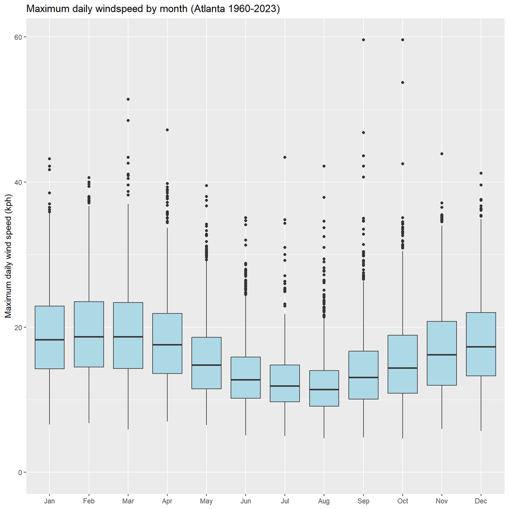

```r
dfDailyATL %>%
    mutate(month=factor(month(date), levels=1:12, labels=month.abb), year=year(date)) %>%
    select(month, windspeed_10m_max) %>%
    ggplot(aes(x=month, y=windspeed_10m_max)) +
    geom_boxplot(fill="lightblue") +
    lims(y=c(0, NA)) +
    labs(x=NULL,
         y="Maximum daily wind speed (kph)",
         title="Maximum daily windspeed by month (Atlanta 1960-2023)"
         )
```

Boxplots for precipitation are created:

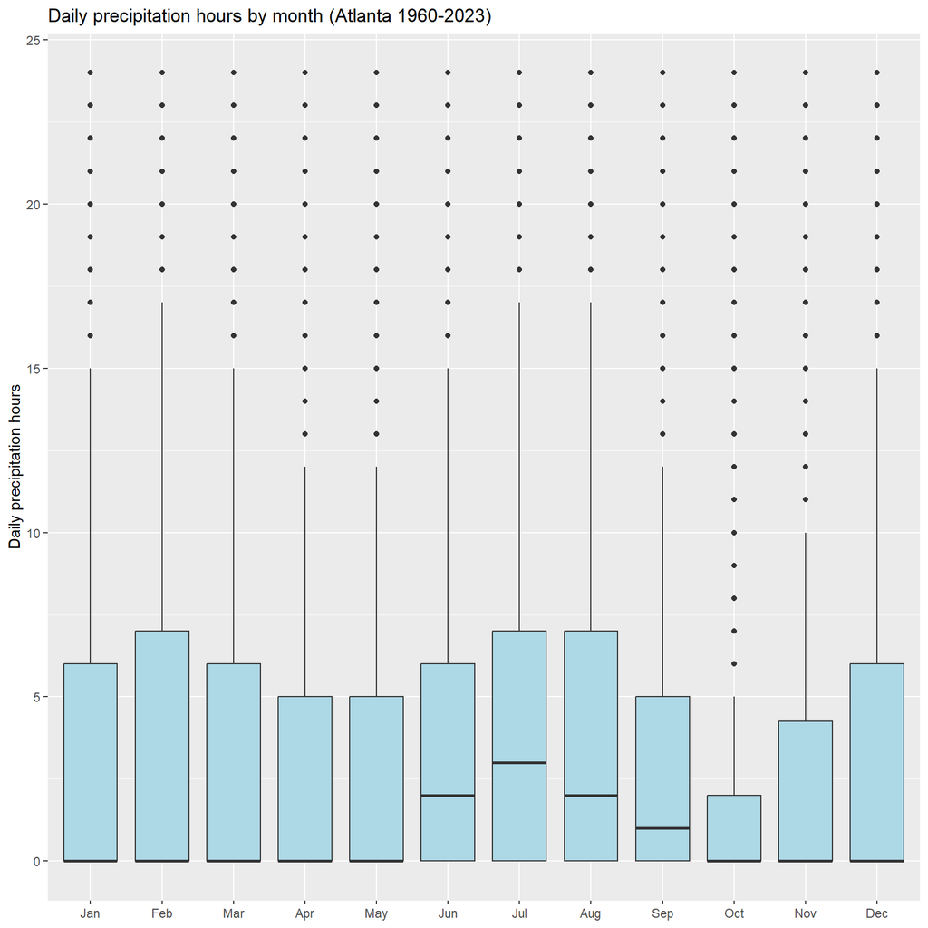

```r
dfDailyATL %>%
    mutate(month=factor(month(date), levels=1:12, labels=month.abb), year=year(date)) %>%
    select(month, precipitation_hours) %>%
    ggplot(aes(x=month, y=precipitation_hours)) +
    geom_boxplot(fill="lightblue") +
    lims(y=c(0, NA)) +
    labs(x=NULL,
         y="Daily precipitation hours",
         title="Daily precipitation hours by month (Atlanta 1960-2023)"
         )
```

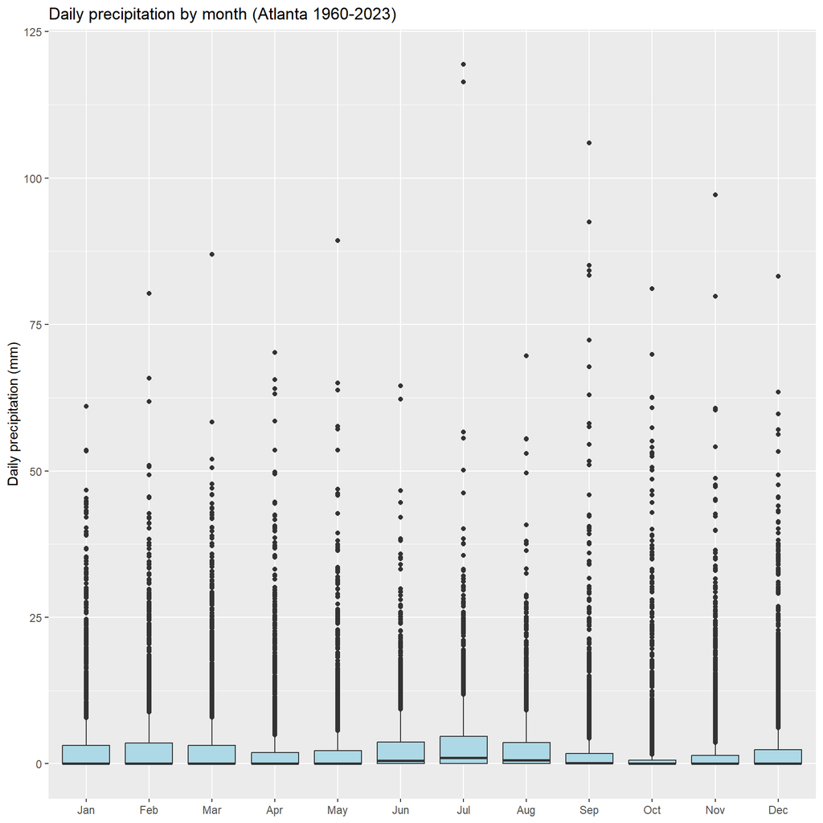

```r
dfDailyATL %>%
    mutate(month=factor(month(date), levels=1:12, labels=month.abb), year=year(date)) %>%
    select(month, precipitation_sum) %>%
    ggplot(aes(x=month, y=precipitation_sum)) +
    geom_boxplot(fill="lightblue") +
    lims(y=c(0, NA)) +
    labs(x=NULL,
         y="Daily precipitation (mm)",
         title="Daily precipitation by month (Atlanta 1960-2023)"
         )
```

Boxplots for temperature are created:

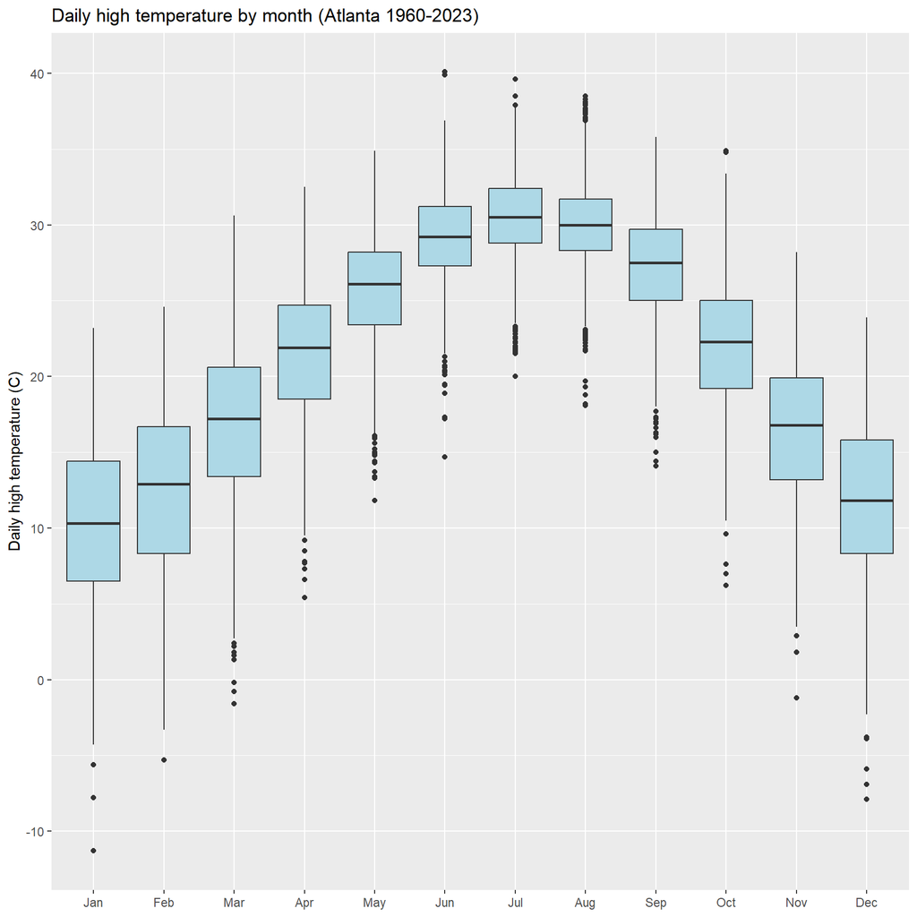

```r
dfDailyATL %>%
    mutate(month=factor(month(date), levels=1:12, labels=month.abb), year=year(date)) %>%
    select(month, temperature_2m_max) %>%
    ggplot(aes(x=month, y=temperature_2m_max)) +
    geom_boxplot(fill="lightblue") +
    labs(x=NULL,
         y="Daily high temperature (C)",
         title="Daily high temperature by month (Atlanta 1960-2023)"
         )
```

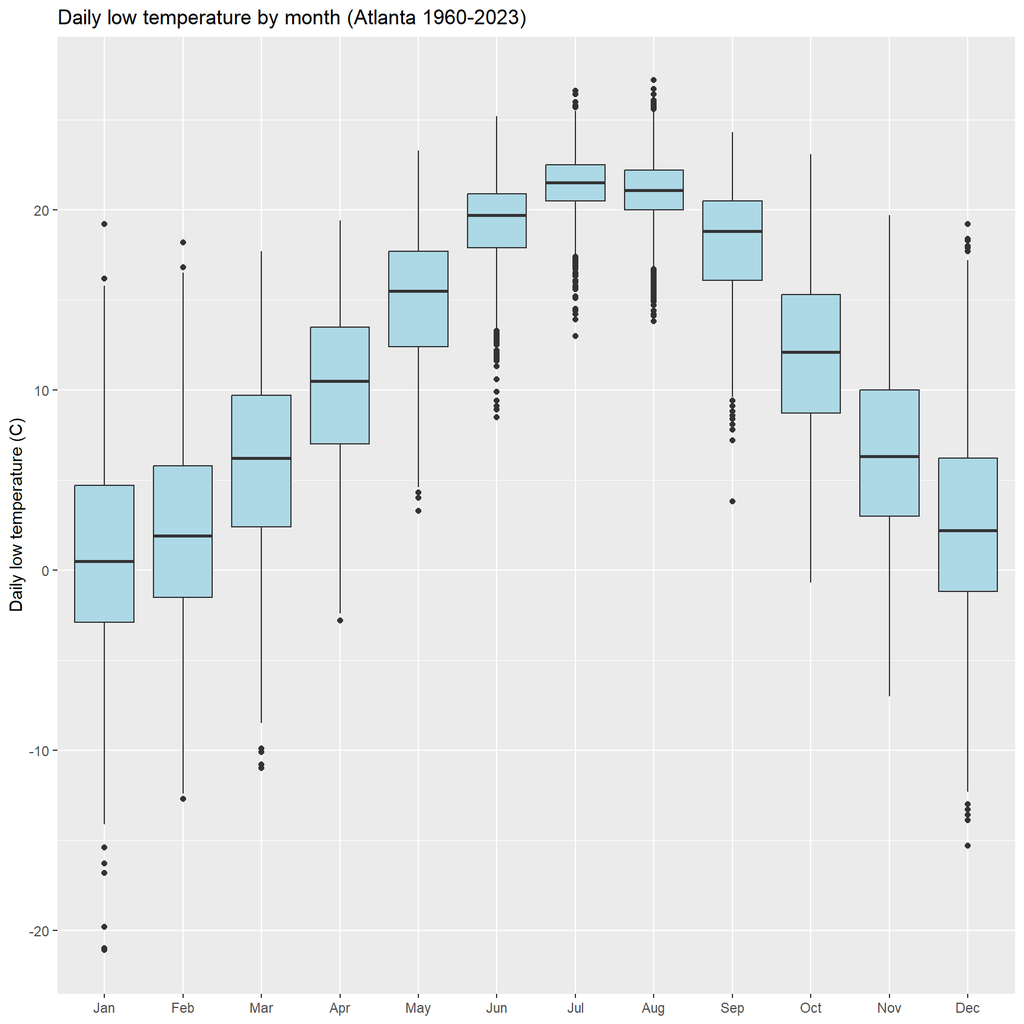

```r
dfDailyATL %>%
    mutate(month=factor(month(date), levels=1:12, labels=month.abb), year=year(date)) %>%
    select(month, temperature_2m_min) %>%
    ggplot(aes(x=month, y=temperature_2m_min)) +
    geom_boxplot(fill="lightblue") +
    labs(x=NULL,
         y="Daily low temperature (C)",
         title="Daily low temperature by month (Atlanta 1960-2023)"
         )
```

ACF and PACF are explored for maximum temperature:

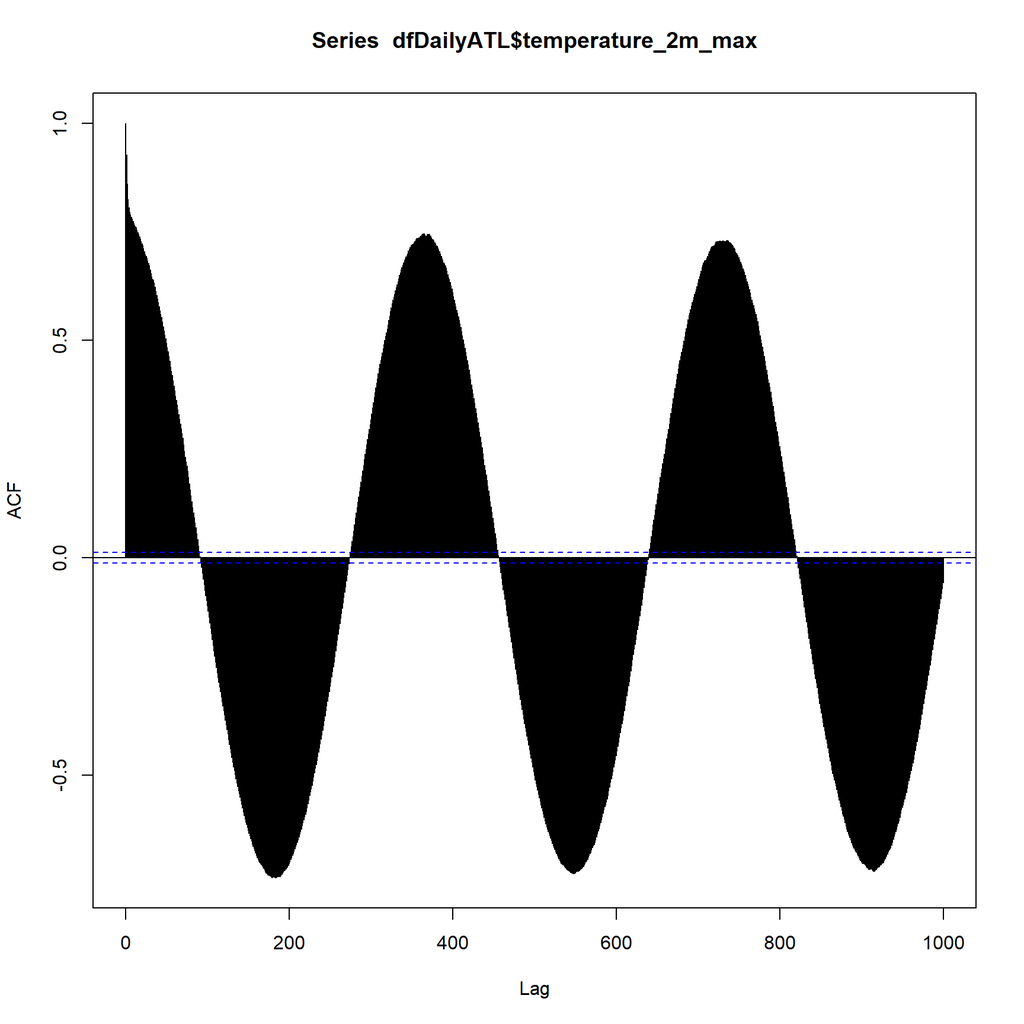

```r
acfTemp <- acf(dfDailyATL$temperature_2m_max, lag.max=1000)
```

```r
as.vector(acfTemp$acf) %>% findPeaks(width=21) %>% which()
```

```
## [1] 365 737
```

```r
as.vector(acfTemp$acf) %>% findPeaks(width=21, FUN=min) %>% which()
```

```
## [1] 185 549 916
```

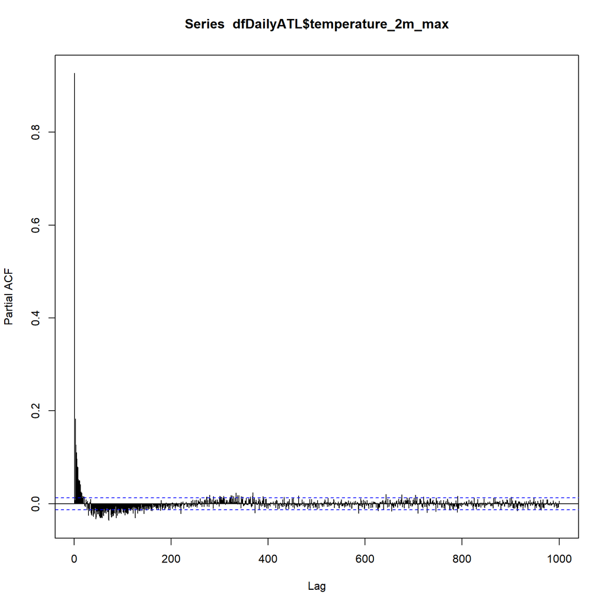

```r
pacfTemp <- pacf(dfDailyATL$temperature_2m_max, lag.max=1000)
```

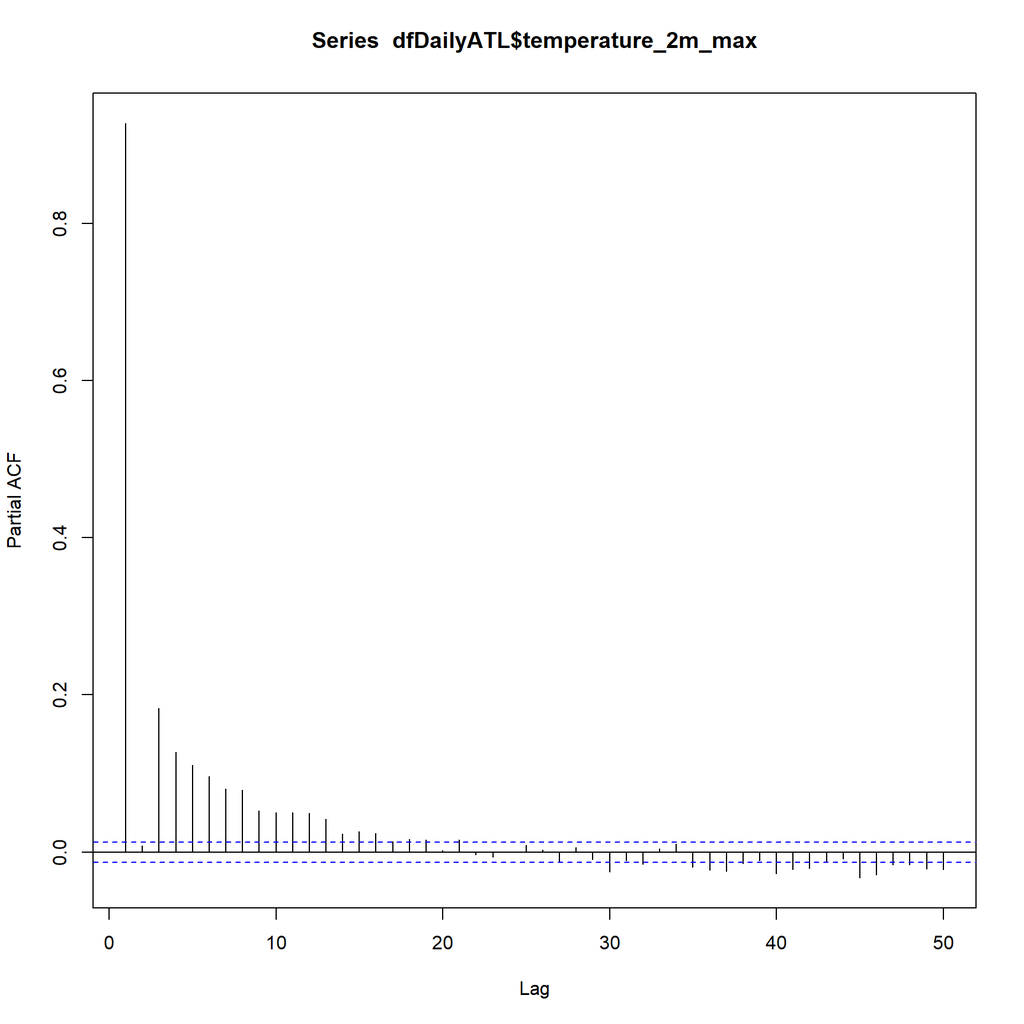

```r
pacf(dfDailyATL$temperature_2m_max, lag.max=50)
```

As expected, ACF has a sustained seasonal pattern, with peaks (at roughly intervals of 365) and valleys (at roughly intervals of 365 offset by roughly 185) corresponding to the 365-day year

ACF and PACF are explored for precipitation:

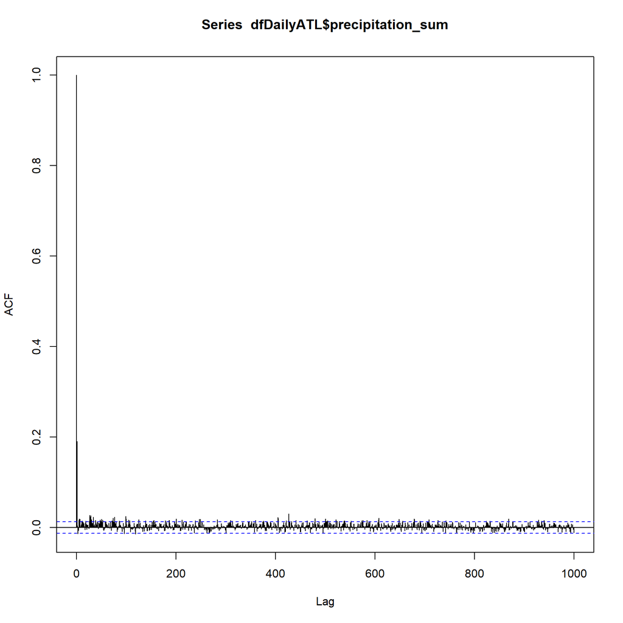

```r
acfPrecip <- acf(dfDailyATL$precipitation_sum, lag.max=1000)
```

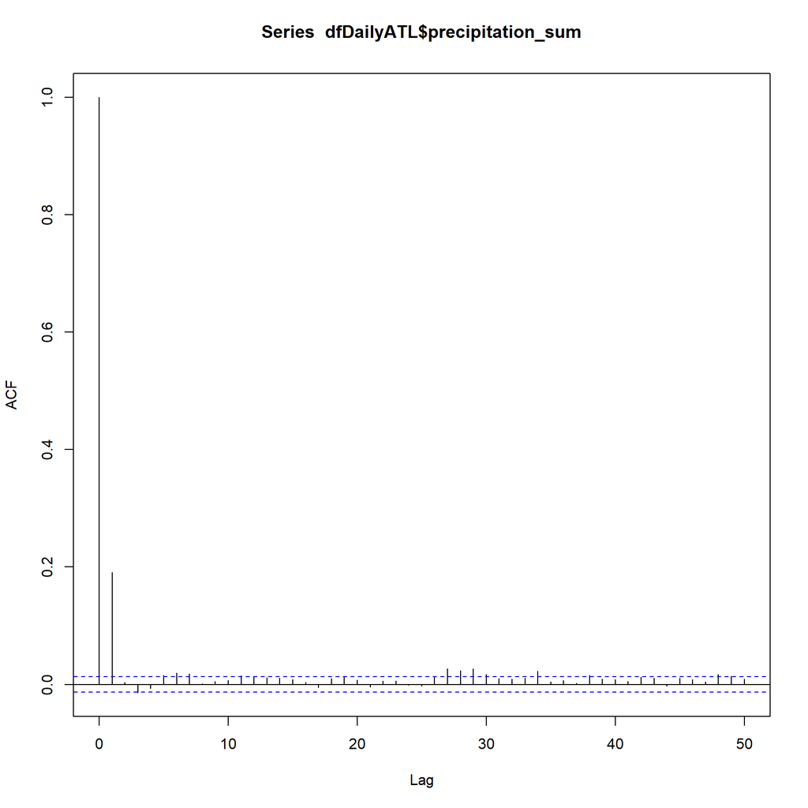

```r
acf(dfDailyATL$precipitation_sum, lag.max=50)
```

```r
as.vector(acfPrecip$acf) %>% findPeaks(width=21) %>% which()
```

```
##  [1]  28  52  78 100 126 140 157 187 202 213 250 284 311 335 361 377 406 428 442
## [20] 465 481 502 523 540 553 585 609 636 650 680 692 710 728 744 757 769 791 803
## [39] 825 852 870 897 913 930 941 961 989
```

```r
as.vector(acfPrecip$acf) %>% findPeaks(width=21, FUN=min) %>% which()
```

```
##  [1]  18  56  71  97 120 134 166 178 195 210 226 238 268 288 302 320 332 344 359
## [20] 383 409 420 438 452 471 483 497 533 551 565 581 598 613 633 654 676 695 719
## [39] 743 766 799 812 842 862 902 920 948 977
```

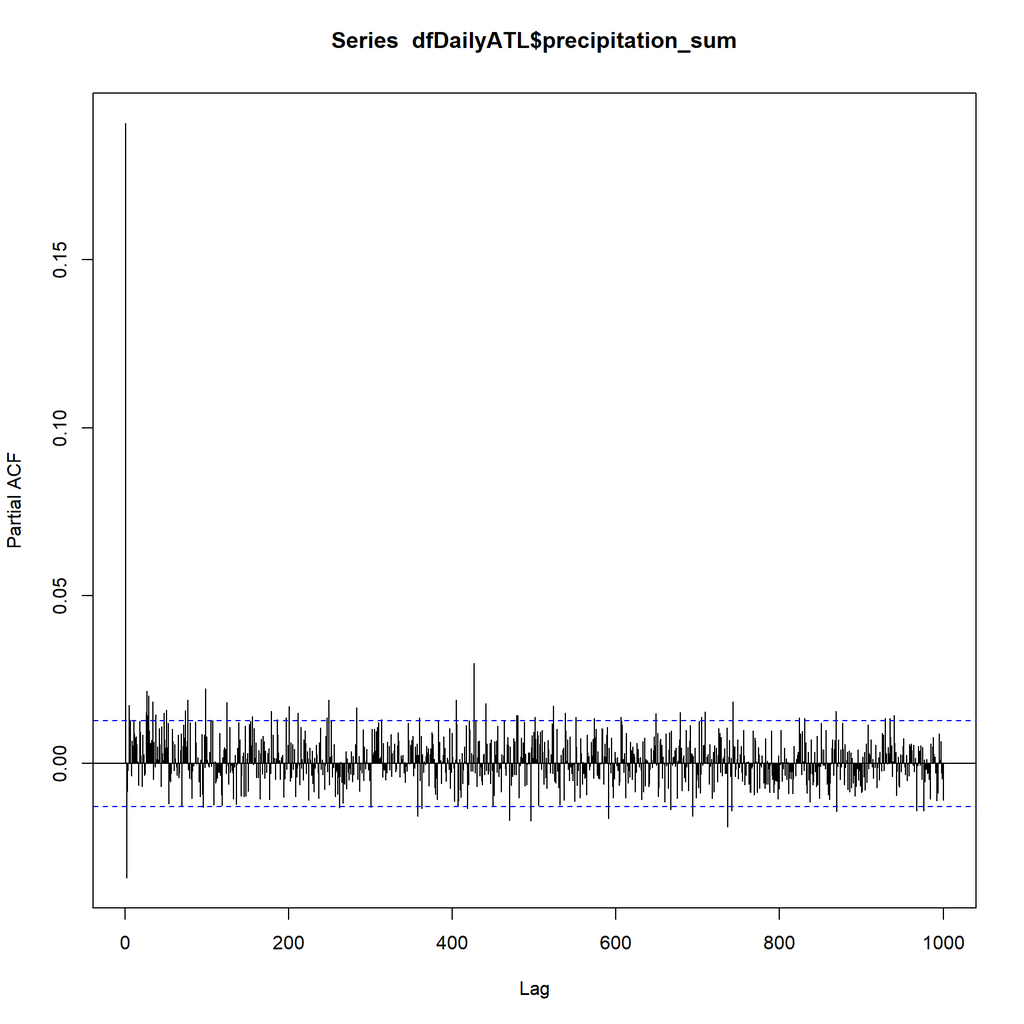

```r
pacfPrecip <- pacf(dfDailyATL$precipitation_sum, lag.max=1000)
```

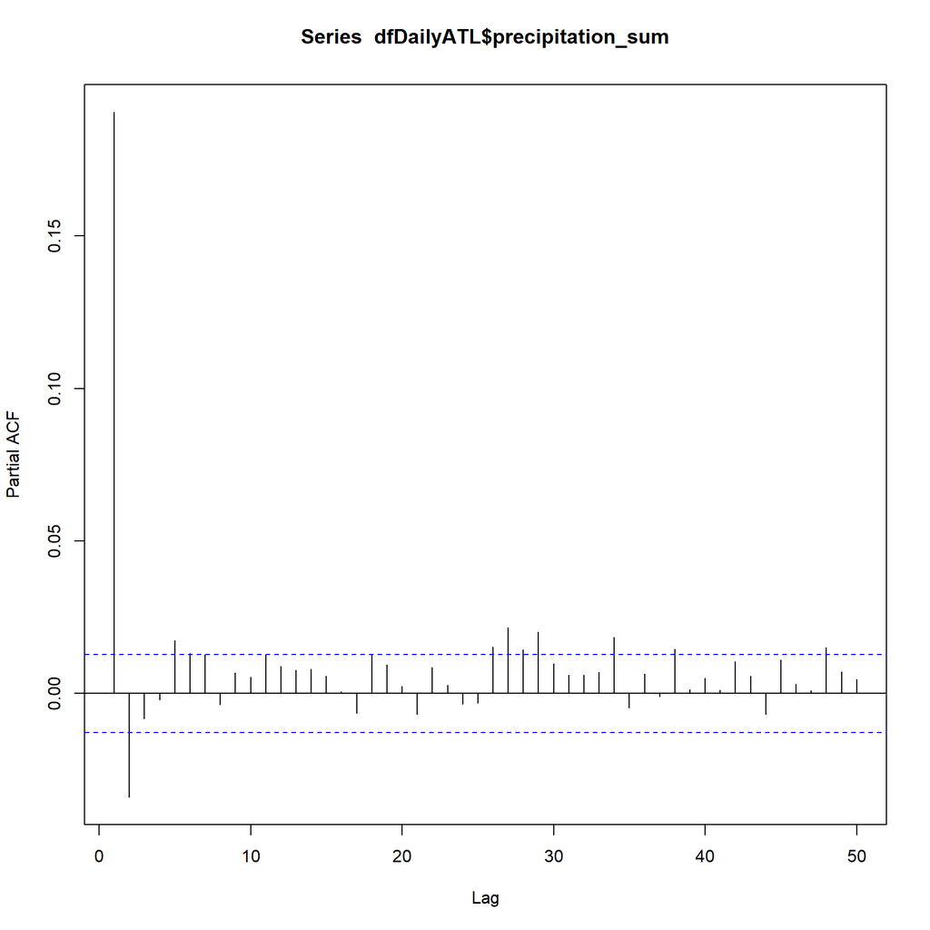

```r
pacf(dfDailyATL$precipitation_sum, lag.max=50)
```

Precipitation by contrast has little seasonality and mostly just a correlation to the previous day’s value

ACF and PACF are explored for windspeed:

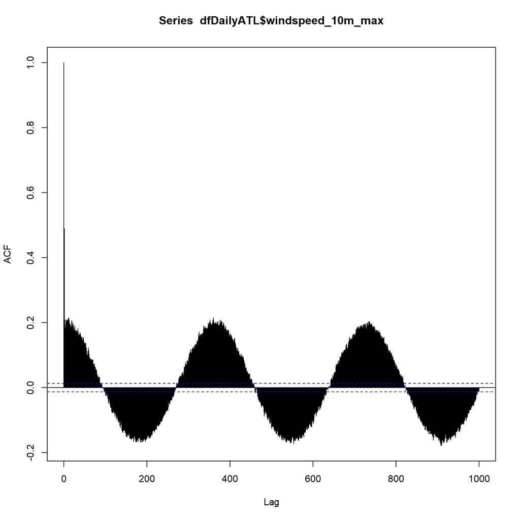

```r
acfWind <- acf(dfDailyATL$windspeed_10m_max, lag.max=1000)
```

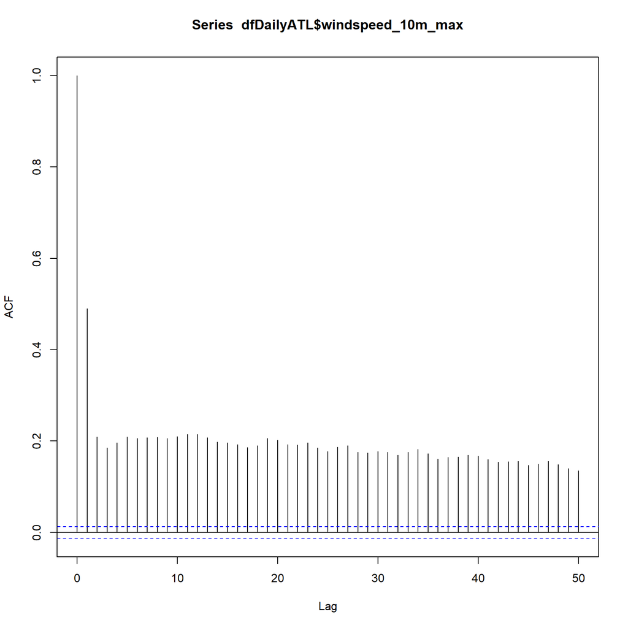

```r
acf(dfDailyATL$windspeed_10m_max, lag.max=50)
```

```r
as.vector(acfWind$acf) %>% findPeaks(width=21) %>% which()
```

```
##  [1]  13 172 183 338 361 378 553 738 894 921
```

```r
as.vector(acfWind$acf) %>% findPeaks(width=21, FUN=min) %>% which()
```

```
## [1] 174 185 555 730 891 910 944
```

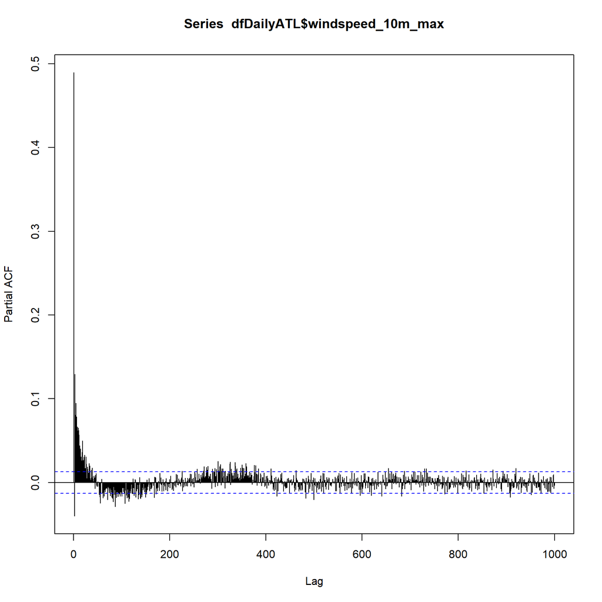

```r
pacfWind <- pacf(dfDailyATL$windspeed_10m_max, lag.max=1000)
```

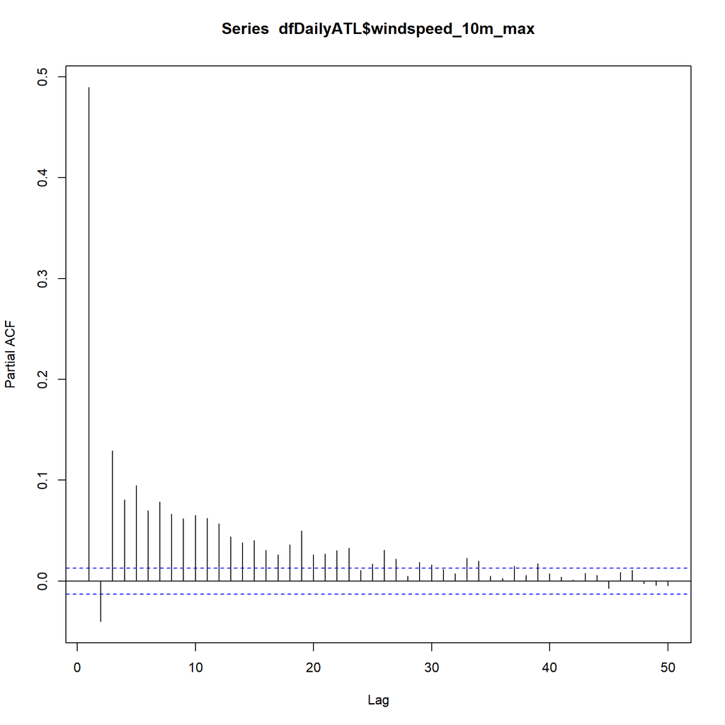

```r
pacf(dfDailyATL$windspeed_10m_max, lag.max=50)
```

Similar to temperature, wind speed appears to have a sustained seasonal component, though peak correlations are much lower in magnitude (~0.2 for wind speed vs. ~0.75 for temperature)

A boxplot for delta daily temperature is created:

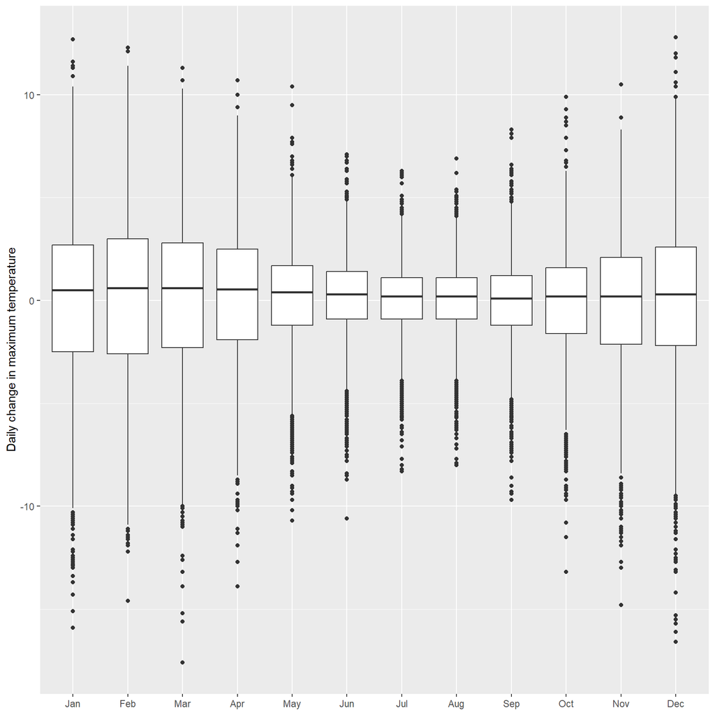

```r
dfDailyATL %>%
    mutate(month=factor(month.abb[month(date)], levels=month.abb),
           chg=temperature_2m_max-lag(temperature_2m_max)
           ) %>%
    filter(!is.na(chg)) %>%
    ggplot(aes(x=month, y=chg)) +
    geom_boxplot() +
    labs(x=NULL, y="Daily change in maximum temperature")
```

Daily temperature changes are generally larger in magnitude during the colder season

A boxplot for delta daily wind speed is created:

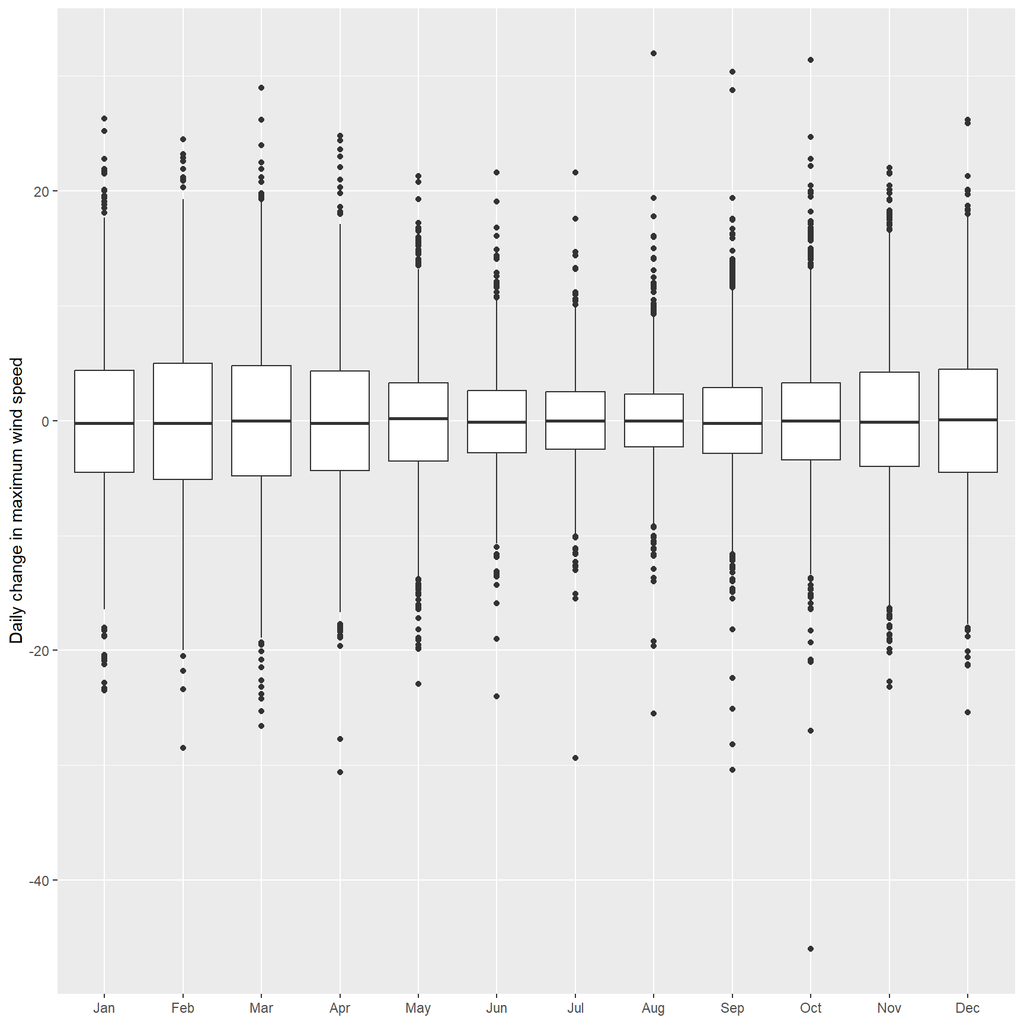

```r
dfDailyATL %>%
    mutate(month=factor(month.abb[month(date)], levels=month.abb),
           chg=windspeed_10m_max-lag(windspeed_10m_max)
           ) %>%
    filter(!is.na(chg)) %>%
    ggplot(aes(x=month, y=chg)) +
    geom_boxplot() +
    labs(x=NULL, y="Daily change in maximum wind speed")
```

Daily wind speed changes are generally larger in magnitude during the colder season